# Construct and criterion validity of the GPQ

Peter ten Klooster

27 August 2024

#### R script for manuscript on the construct and criterion validity of the GPQ. Data used from the [PERFECTRA trial](https://doi.org/10.1136/rmdopen-2024-004291).

- 21 August 2024: Started with R script
  - Based on PerfectRA script

# Patient assignment and selection

## Included patients

```r
patients <- read_delim(list.files("data/", full.names = TRUE,
                                  pattern = "tih_patients")[[1]],
                       ";", escape_double = F,
                       col_types = cols(
                        id = col_integer(),
                        center_id = col_character(),
                        birthyear = col_double(),
                        gender = col_factor(levels =

                                                    c("female","male")),
                        unique_id = col_integer(),
                        last_activity = col_datetime("%Y-%m-%d %H:%M:%S"),
                        died_on = col_datetime(format = "%Y-%m-%d %H:%M:%S"),
                        show_prev_visits = col_double()
                        ))
problems(patients)
```

```
## # A tibble: 0 × 5
## # ℹ 5 variables: row <int>, col <int>, expected <chr>, actual <chr>, file <chr>
```

Clean and sort patient dataset

```r
patients <-
  patients %>%
  dplyr::select(id, center_id, birthyear, gender, unique_id, died_on) %>%
  # Rename id to match with other data frames
  rename(patient_id = id) %>%
  # Sort by patient_id
  arrange(patient_id)

head(patients)
```

```
## # A tibble: 6 × 6
##   patient_id center_id birthyear gender  unique_id died_on
##        <int> <chr>         <dbl> <fct>       <int> <dttm>
## 1      42016 14             1972 male   1277973119 NA
## 2      54569 47             1959 female 1444897159 NA
## 3     143724 65             1963 male   1610575431 NA
## 4     212245 14             1961 female   66506019 NA
## 5     292274 69             1964 female 2006543114 NA
## 6     333949 38             1981 male   1421895841 NA
```

## Treatment assignment

Retrieve randomization information from `overview` table:

```r
randomization <- read_delim(list.files("data/", full.names = TRUE,
                                       pattern = "overview")[[1]], ";",
                            escape_double = F,
                            col_types = cols(
                              patient_id = col_integer(),
                              condition = col_factor(),
                              start_date = col_datetime(format = "%d-%m-%Y"),
                              stop_date = col_datetime(format = "%d-%m-%Y"),
                              stop_reason = col_factor()
                            )) %>%
  # Sort by patient_id
  arrange(patient_id) %>%
  # Recode condition
  mutate(condition = dplyr::recode(condition,
                          'Bari' = "1",
                          'TNF' = "0")) %>%
  # Compute inclusion year
  mutate(start_year = start_date) %>%
  mutate(start_year = year(start_year))



count(randomization, condition)
```

```
## # A tibble: 2 × 2
##   condition     n
##   <fct>     <int>
## 1 0           103
## 2 1            98
```

## Patient selection

Remove patients that were inadvertently included (stop_reason = 5)

```r
randomization <- subset(randomization, stop_reason != 5 | is.na(stop_reason))
randomization$condition <- droplevels(randomization$condition)

count(randomization, condition) # One patient in each condition removed
```

```
## # A tibble: 2 × 2
##   condition     n
##   <fct>     <int>
## 1 0           102
## 2 1            97
```

## List number of patients by group that discontinued with the study plus stopreason

```r
randomization <- randomization %>%
  mutate(
    # Compute difference in weeks between start and stop dates
    diff_stop_study_weeks = as.numeric(difftime(stop_date, start_date, units = "weeks"))
    ) %>%
  # Create a new variable for stopped within 48 weeks (zero in all other cases)
  mutate(stopped_study = ifelse(diff_stop_study_weeks < 48, 1, 0))

  # Summarize the number and reasons of dropout per condition
  # Filter data for 'stopped' equals 1
  filtered_data <- randomization %>%
    dplyr::filter(stopped_study == 1)

# Summarize 'stop_reason' by 'condition'
  summary <- filtered_data %>%
    group_by(condition, stop_reason) %>%
    summarise(count = n(), .groups = "drop")
  summary
```

```
## # A tibble: 6 × 3
##   condition stop_reason count
##   <fct>     <fct>       <int>
## 1 0         4               9
## 2 0         999             3
## 3 0         3               1
## 4 1         4               4
## 5 1         6               1
## 6 1         999             1
```

```r
# Stop_reason 1 = Deceased
# Stop_reason 2 = Moved
# Stop_reason 3 = Comorbidity
# Stop_reason 4 = Patient's own decision
# Stop_reason 5 = Inadvertently included
# Stop_reason 6 = Medication-free remission
# Stop_reason 7 = Study completed
# Stop_reason 999 = Unknown/NA
```

## Merge `patients` and `randomization` dataframes into `sample` dataframe:

```r
sample <- patients %>%
  # right_join to only keep correctly included patients in the sample
  right_join(randomization, by = "patient_id") %>%
  # Compute age
  rename(age = birthyear) %>%
  mutate(age = (start_year - age))

count(sample, condition)
```

```
## # A tibble: 2 × 2
##   condition     n
##   <fct>     <int>
## 1 0           102
## 2 1            97
```

# Merging baseline sociodemographic and clinical characteristics

## Sociodemographics

```r
sociodemo <- read_delim(list.files("data/", full.names = TRUE,
                                   pattern = "questionnaire_sociodemo")[[1]],
                        ";", escape_double = F,
                        col_types = cols(
                        id = col_integer(),
                        cohabitation_setting = col_character(),
                        highest_education = col_character(),
                        current_living_situation_1 = col_character(),
                        current_living_situation_2 = col_character(),
                        current_living_situation_3 = col_character(),
                        current_living_situation_4 = col_character(),
                        current_living_situation_5 = col_character(),
                        current_living_situation_6 = col_character(),
                        current_living_situation_7 = col_character(),
                        current_living_situation_8 = col_character(),
                        current_living_situation_9 = col_character(),
                        smoking = col_character(),
                        smoking_amount = col_integer(),
                        smoking_period = col_integer(),
                        alcohol = col_character(),
                        alcohol_amount_week = col_integer(),
                        date = col_datetime("%Y-%m-%d"),
                        duration = col_integer(),
                        entered_by_user_id = col_character(),
                        entered_on = col_datetime("%Y-%m-%d %H:%M:%S"),
                        changed_by_user_id = col_character(),
                        changed_on = col_datetime("%Y-%m-%d %H:%M:%S"),
                        patient_id = col_integer()
                        ))
```

Cleaning dataset and removing double entries

```r
sociodemo <- sociodemo %>%
  # Rename date to match dataframe
  rename(date_sociodemo = date) %>%
  # moving patient_id and date to first two columns
  dplyr::select(patient_id, date_sociodemo, everything()) %>%
  # Sort by patient_id and date
  arrange(patient_id, date_sociodemo) %>%
  # For now, select last entry for duplicate entries
  group_by(patient_id) %>%
  filter(row_number() == n()) %>%
  # Recode smoking
  mutate(smoking = dplyr::recode(smoking,
                          '1' = "No (never)",
                          '2' = "No (stopped)",
                          '3' = "Yes")) %>%
  # Recode alcohol
  mutate(alcohol = dplyr::recode(alcohol,
                          '1' = "No",
                          '2' = "Yes")) %>%
  # Remove unnecessary columns
  dplyr::select(-id, -duration, -entered_by_user_id, -entered_on,
         -changed_by_user_id, -changed_on)
```

Merge `sociodemo` with `sample` dataframe:

```r
sample <- sample %>%
  # left_join to keep all patients in the sample
  left_join(sociodemo, by = "patient_id")

sum(is.na(sample$date_sociodemo))
```

```
## [1] 2
```

```r
# Number of patients with missing sociodemographic data
```

## Disease duration

```r
start_ra <- read_delim(list.files("data/", full.names = TRUE,
                                  pattern = "questionnaire_start_ra")[[1]],
                       ";", escape_double = F,
                       col_types = cols(
                        id = col_integer(),
                        patient_id = col_integer(),
                        date = col_datetime("%Y-%m-%d"),
                        duration = col_integer(),
                        entered_by_user_id = col_character(),
                        entered_on = col_datetime("%Y-%m-%d %H:%M:%S"),
                        changed_by_user_id = col_character(),
                        changed_on = col_datetime("%Y-%m-%d %H:%M:%S")
                        ))
```

Cleaning dataset and removing double entries

```r
start_ra <- start_ra %>%
  # Rename date to match with dataframe
  rename(date_start_ra = date) %>%
  # moving patient_id and date to first two columns
  dplyr::select(patient_id, date_start_ra, everything()) %>%
  # Sort by patient_id and date
  arrange(patient_id, desc(entered_on)) %>%
  # Select last entry for duplicate entries (addition after monitoring)
  group_by(patient_id) %>%
  mutate(rn = row_number()) %>%
  arrange(patient_id, rn) %>%
  filter(row_number() == n() | rn == 1) %>%
  filter(rn <= 1) %>%
  # Remove unnecessary columns
  dplyr::select(-id, -duration, -entered_by_user_id, -entered_on,
         -changed_by_user_id, -changed_on, -rn)
```

Merge `start_ra` with `sample` dataframe:

```r
sample <- sample %>%
  # left_join to keep all patients in the sample
  left_join(start_ra, by = "patient_id") %>%
  # Compute disease duration
  rename(disease_duration_years = rheumatism_since_year) %>%
  mutate(disease_duration_years = (start_year - disease_duration_years))

sum(is.na(sample$date_start_ra))
```

```
## [1] 0
```

```r
# Number of patients with missings
```

## BMI

```r
bmi <- read_delim(list.files("data/", full.names = TRUE,
                             pattern = "patient_bmi")[[1]],
                  ";", escape_double = F, col_types = cols(
                        id = col_integer(),
                        length = col_integer(),
                        weight = col_integer(),
                        bmi = col_integer(),
                        date = col_datetime("%Y-%m-%d"),
                        duration = col_integer(),
                        entered_by_user_id = col_character(),
                        entered_on = col_datetime("%Y-%m-%d %H:%M:%S"),
                        changed_by_user_id = col_character(),
                        changed_on = col_datetime("%Y-%m-%d %H:%M:%S"),
                        patient_id = col_integer()
                        ))
```

Cleaning dataset and removing double entries

```r
bmi <- bmi %>%
  # Rename date to match with dataframe
  rename(date_bmi = date) %>%
  # moving patient_id and date to first two columns
  dplyr::select(patient_id, date_bmi, everything()) %>%
  # Sort by patient_id and date
  arrange(patient_id, desc(entered_on)) %>%
  # For now, select first entry for duplicate entries
  group_by(patient_id) %>%
  mutate(rn = row_number()) %>%
  arrange(patient_id, rn) %>%
  filter(row_number() == n() | rn == 1) %>%
  filter(rn <= 1) %>%
  # Remove unnecessary columns
  dplyr::select(-id, -duration, -entered_by_user_id, -entered_on,
         -changed_by_user_id, -changed_on, -rn)
```

Merge `bmi` with `sample` dataframe:

```r
sample <- sample %>%
  # left_join to keep all patients in the sample
  left_join(bmi, by = "patient_id")

sum(is.na(sample$date_bmi))
```

```
## [1] 2
```

```r
# Number of patients with missings
```

## Erosions

```r
rontgen <- read_delim(list.files("data/", full.names = TRUE,
                                 pattern =  "questionnaire_rontgen")[[1]],
                       ";", escape_double = F,
                       col_types = cols(
                        id = col_integer(),
                        measurement = col_character(),
                        erosions = col_character(),
                        date = col_datetime("%Y-%m-%d"),
                        duration = col_integer(),
                        entered_by_user_id = col_character(),
                        entered_on = col_datetime("%Y-%m-%d %H:%M:%S"),
                        changed_by_user_id = col_character(),
                        changed_on = col_datetime("%Y-%m-%d %H:%M:%S"),
                        patient_id = col_integer()
                        ))
```

Cleaning dataset and removing double entries

```r
rontgen <- rontgen %>%
  # Rename date to match with dataframe
  rename(date_rontgen = date) %>%
  # moving patient_id and date to first two columns
  dplyr::select(patient_id, date_rontgen, everything()) %>%
  # Sort by patient_id and date
  arrange(patient_id, desc(entered_on)) %>%
  # Select last entry for duplicate entries (addition after monitoring)
  group_by(patient_id) %>%
  mutate(rn = row_number()) %>%
  arrange(patient_id, rn) %>%
  filter(row_number() == n() | rn == 1) %>%
  filter(rn <= 1) %>%
  # Recode erosions
  mutate(erosions = dplyr::recode(erosions,
                          '1' = "Yes",
                          '2' = "No",
                          '3' = "Unknown")) %>%
  # Remove unnecessary columns
  dplyr::select(-id, -measurement, -duration, -entered_by_user_id, -entered_on,
         -changed_by_user_id, -changed_on, -rn) %>%
  # Recode erosions
  mutate(erosions = dplyr::recode(erosions,
                          '2' = "0",
                          '3' = "3")) # 0 = No, 1 = Yes, 3 = Unknown
```

Merge `rontgen` with `sample` dataframe:

```r
sample <- sample %>%
  # left_join to keep all patients in the sample
  left_join(rontgen, by = "patient_id")

sum(is.na(sample$date_rontgen))
```

```
## [1] 0
```

```r
# Number of patients with missings
```

## Rheumatoid Factor (RF)

```r
rheumatismfactor <- read_delim(list.files("data/", full.names = TRUE,
                      pattern = "questionnaire_rheumatismfactor")[[1]],
                       ";", escape_double = F,
                       col_types = cols(
                        id = col_integer(),
                        reumafactor = col_character(),
                        reumafactor_amount = col_integer(),
                        reumafactor_date = col_datetime("%Y-%m-%d"),
                        date = col_datetime("%Y-%m-%d"),
                        duration = col_integer(),
                        entered_by_user_id = col_character(),
                        entered_on = col_datetime("%Y-%m-%d %H:%M:%S"),
                        changed_by_user_id = col_character(),
                        changed_on = col_datetime("%Y-%m-%d %H:%M:%S"),
                        patient_id = col_integer()
                        ))
```

Cleaning dataset and removing double entries

```r
rheumatismfactor <- rheumatismfactor %>%
  # Rename date to match with dataframe
  rename(rf = reumafactor, rf_amount = reumafactor_amount,
         rf_date = reumafactor_date, date_rheumatismfactor = date) %>%
  # moving patient_id and date to first two columns
  dplyr::select(patient_id, date_rheumatismfactor, everything()) %>%

  # For duplicate entries, once RF positive -> always RF positive!
  # Sort by patient_id and rf
  group_by(patient_id, rf) %>%
  mutate(rn = row_number()) %>%
  arrange(patient_id, rn) %>%
  filter(row_number() == n() | rn == 1) %>%
  filter(rn <= 1) %>%
  dplyr::select(-rn) %>%

  # Sort by patient_id and date
  arrange(patient_id, rf) %>%

  # Select last entry for remaining duplicate entries (addition after monitoring)
  group_by(patient_id) %>%
  mutate(rn = row_number()) %>%
  arrange(patient_id, rn) %>%
  filter(row_number() == n() | rn == 1) %>%
  filter(rn <= 1) %>%

  # Recode rheumatismfactor
  mutate(rf = dplyr::recode(rf,
                            '1' = "Positive",
                            '2' = "Negative",
                            '3' = "Unknown")) %>%

  # Remove unnecessary columns
  dplyr::select(-id, -duration, -entered_by_user_id, -entered_on,
                -changed_by_user_id, -changed_on)
```

Merge `rheumatismfactor` with `sample` dataframe:

```r
sample <- sample %>%
  # left_join to keep all patients in the sample
  left_join(rheumatismfactor, by = "patient_id")

sum(is.na(sample$date_rheumatismfactor))
```

```
## [1] 0
```

```r
# Number of patients with missings
```

## Anti-CCP

```r
anticcp <- read_delim(list.files("data/", full.names = TRUE,
                                 pattern = "questionnaire_anticcp")[[1]],
                       ";", escape_double = F,
                       col_types = cols(
                        id = col_integer(),
                        anticcp = col_character(),
                        anticcp_date = col_datetime("%Y-%m-%d"),
                        date = col_datetime("%Y-%m-%d"),
                        duration = col_integer(),
                        entered_by_user_id = col_character(),
                        entered_on = col_datetime("%Y-%m-%d %H:%M:%S"),
                        changed_by_user_id = col_character(),
                        changed_on = col_datetime("%Y-%m-%d %H:%M:%S"),
                        patient_id = col_integer()
                        ))
```

Cleaning dataset and removing double entries

```r
anticcp <- anticcp %>%
  # Rename date to match with dataframe
  rename(date_anticcp = date) %>%
  # moving patient_id and date to first two columns
  dplyr::select(patient_id, date_anticcp, everything()) %>%
  # Recode rheumatismfactor
  mutate(anticcp = dplyr::recode(anticcp,
                          '2' = "Negative",
                          '1' = "Positive")) %>%

  # For duplicate entries, once ACPA positive -> always ACPA positive!
  # Sort by patient_id and anticcp
  arrange(patient_id, anticcp) %>%
  group_by(patient_id) %>%
  filter(row_number() == n()) %>%

  # For remaining duplicate entries (shouldn't be possible) -> keep most recent
  # Sort by patient_id and rf
  arrange(patient_id, date_anticcp) %>%
  group_by(patient_id) %>%
  filter(row_number() == n()) %>%

  # Remove unnecessary columns
  dplyr::select(-id, -duration, -entered_by_user_id, -entered_on,
                -changed_by_user_id, -changed_on)
```

Merge `anticcp` with `sample` dataframe:

```r
sample <- sample %>%
  # left_join to keep all patients in the sample
  left_join(anticcp, by = "patient_id")

sum(is.na(sample$date_anticcp))
```

```
## [1] 0
```

```r
# Number of patients with missings
```

## Comorbidities

```r
comorbidity <- read_delim(list.files("data/", full.names = TRUE,
                                     pattern = "questionnaire_perfect_comorbidity")[[1]],
                       ";", escape_double = F,
                       col_types = cols(
                        id = col_integer(),
                        patient_id = col_integer(),
                        cardiovasculaire_ziekte = col_character(),
                        maligniteiten = col_character(),
                        infecties = col_character(),
                        gastro_intestinale_ziekte = col_character(),
                        osteoporose = col_character(),
                        depressie = col_character(),
                        date = col_datetime("%Y-%m-%d"),
                        duration = col_integer(),
                        entered_by_user_id = col_character(),
                        entered_on = col_datetime("%Y-%m-%d %H:%M:%S"),
                        changed_by_user_id = col_character(),
                        changed_on = col_datetime("%Y-%m-%d %H:%M:%S"),
                        patient_id = col_integer()
                        ))
```

Cleaning dataset and removing double entries

```r
comorbidity <- comorbidity %>%
  # Rename date to match with dataframe
  rename(date_comorbidity = date,
         cardiovascular_disease = cardiovasculaire_ziekte,
         malignancy = maligniteiten,
         infections = infecties,
         gastro_intestinal_disease = gastro_intestinale_ziekte,
         osteoporosis = osteoporose,
         depression = depressie) %>%
  # moving patient_id and date to first two columns
  dplyr::select(patient_id, date_comorbidity, everything()) %>%
  # Sort by patient_id and date
  arrange(patient_id, desc(entered_on)) %>%
  # select last entry for duplicate entries (addition after monitoring)
  group_by(patient_id) %>%
  mutate(rn = row_number()) %>%
  arrange(patient_id, rn) %>%
  filter(row_number() == n() | rn == 1) %>%
  filter(rn <= 1) %>%
  # Recode comorbidity scores
  mutate_at(vars(cardiovascular_disease:depression), ~recode(.,
                                      '1' = "Yes",
                                      '0' = "No")) %>%
  # Remove unnecessary columns
  dplyr::select(-id, -duration, -entered_by_user_id, -entered_on,
                -changed_by_user_id, -changed_on, -rn)
```

Merge `comorbidity` with `sample` dataframe:

```r
sample <- sample %>%
  # left_join to keep all patients in the sample
  left_join(comorbidity, by = "patient_id")

sum(is.na(sample$date_comorbidity))
```

```
## [1] 0
```

```r
# Number of patients with missings
```

## Patient medication

```r
patient_medication <- read_delim(list.files("data/", full.names = TRUE,
                              pattern = "patient_medication")[[1]],
                       ";", escape_double = F,
                       col_types = cols(.default = "c",
                        id = col_integer(),
                        stopreason_id = col_integer(),
                        medicine_id = col_integer(),
                        route_id = col_integer(),
                        frequency_id = col_integer(),
                        unit_id = col_integer(),
                        entered_by_user_id = col_character(),
                        entered_on = col_datetime("%Y-%m-%d %H:%M:%S"),
                        changed_by_user_id = col_character(),
                        changed_on = col_datetime("%Y-%m-%d %H:%M:%S"),
                        othermedicine = col_guess(),
                        dose = col_character(),
                        start_date = col_datetime("%Y-%m-%d"),
                        stop_date = col_datetime("%Y-%m-%d"),
                        stop_text = col_guess(),
                        patient_id = col_integer(),
                        brand = col_guess(),
                        combination_dose = col_character(),
                        indication_id = col_character(),
                        indication_other = col_guess()
                        ))
problems(patient_medication)
```

```
## # A tibble: 0 × 5
## # ℹ 5 variables: row <int>, col <int>, expected <chr>, actual <chr>, file <chr>
```

Compute concomitant MTX use at start bDMARD (example)

```r
mtx <- patient_medication %>%
  # Moving patient_id to first column
  dplyr::select(patient_id, everything()) %>%
  # Remove unnecessary columns
  dplyr::select(-id, -stopreason_id, -route_id, -frequency_id, -unit_id,
                -entered_by_user_id, -entered_on, -changed_by_user_id,
                -changed_on, -othermedicine, -dose, -stop_text, -brand,
                -combination_dose, -indication_id, -indication_other) %>%
  # Select rows for MTX only
  filter(medicine_id == "7") %>%
  # Select only those rows with a valid (non-missing) start_date
  filter(!is.na(start_date)) %>%
  # Sort by patient_id and start_date
  arrange(patient_id, start_date, stop_date) %>%

  # Rename item names
  rename(mtx_start_date = start_date,
         mtx_stop_date = stop_date)
```

Join `mtx` with `start_date`:

```r
mtx <- mtx %>%
  left_join(sample, by = "patient_id") %>%
  mutate(
    # Compute difference in weeks from study (bDMARD) start_date at once for
    # both start and stop dates
    diff_start_weeks = as.numeric(difftime(mtx_start_date, start_date,
                                           units = "weeks")),
    diff_stop_weeks = as.numeric(difftime(mtx_stop_date, start_date,
                                          units = "weeks"))) %>%
    # Filter based on diff_in_weeks for both start and stop dates
  filter((diff_start_weeks <= 0 | is.na(diff_start_weeks)) &
         (diff_stop_weeks > 0 | is.na(diff_stop_weeks))) %>%
  # Group by patient_id and select the last entry for duplicate entries
  group_by(patient_id) %>%
  arrange(desc(mtx_stop_date), desc(mtx_start_date)) %>%
  slice(1) %>%
  # Rename column
  mutate(concomitant_mtx = as.character(row_number())) %>%
  # Select only the necessary columns
  dplyr::select(patient_id, concomitant_mtx)
```

Merge `mtx` with `sample` dataframe:

```r
sample <- sample %>%
  # left_join to keep all patients in the sample
  left_join(mtx, by = "patient_id")

  sum(is.na(sample$concomitant_mtx))
```

```
## [1] 68
```

```r
  # Number of patients with missings (no MTX use)



sample <- sample %>%
  # Recode NA's into 0
  mutate(concomitant_mtx = coalesce(concomitant_mtx, "0")) %>%
  mutate(concomitant_mtx = dplyr::recode(concomitant_mtx,
                          '1' = "Yes",
                          '0' = "No")) %>%
  mutate(erosions = factor(erosions), rf = factor(rf), anticcp = factor(anticcp),
         smoking = factor(smoking), concomitant_mtx = factor(concomitant_mtx))
```

Compute new condition for combi vs mono therapy (Bari+MTX, Bari mono, TNFi+MTX, TNFi mono) as factor vraiable

```r
sample <- sample %>%
  mutate(condition_combi_mono = factor(case_when(
    condition == 0 & concomitant_mtx == "Yes" ~ 2,
    condition == 0 & concomitant_mtx == "No" ~ 3,
    condition == 1 & concomitant_mtx == "Yes" ~ 0,
    condition == 1 & concomitant_mtx == "No" ~ 1,
    TRUE ~ NA_integer_
  ), levels = c(0, 1, 2, 3), labels = c("0", "1", "2", "3")))
```

# Preparing longitudinal disease activity measurements

## DAS28

```r
das28 <- read_delim(list.files("data/", full.names = TRUE,
                               pattern = "questionnaire_das28")[[1]],
                       ";", escape_double = F,
                       col_types = cols(.default = "c",
                        id = col_integer(),
                        tjc28 = col_number(),
                        sjc28 = col_number(),
                        score = col_number(),
                        date = col_datetime("%Y-%m-%d"),
                        duration = col_integer(),
                        entered_by_user_id = col_character(),
                        entered_on = col_datetime("%Y-%m-%d %H:%M:%S"),
                        changed_by_user_id = col_character(),
                        changed_on = col_datetime("%Y-%m-%d %H:%M:%S"),
                        patient_id = col_integer()
                        ))
```

Cleaning dataset

```r
das28 <- das28 %>%
  # Rename date to match dataframe
  rename(date_das28 = date) %>%
  # moving patient_id and date to first two columns
  dplyr::select(patient_id, date_das28, everything()) %>%
  # Sort by patient_id and date
  arrange(patient_id, date_das28) %>%
    # Remove unnecessary columns
  dplyr::select(-id, -rai_tmp_right:-sji_mtpt_left, -duration, -entered_by_user_id,
         -entered_on, -changed_by_user_id, -changed_on)

das28 <- das28 %>%
  # Compute summed joint counts
  rowwise() %>%
  mutate(jc28 = sum(c_across(tjc28:sjc28), na.rm = T)) %>%
  mutate(delta_tsjc28 = tjc28 - sjc28) %>%
  ungroup() %>%
  # Move jc28 column after sjc28
  dplyr::select(patient_id, date_das28, tjc28, sjc28, jc28, everything())
```

Join `das28` with `start_date`:

```r
das28 <- das28 %>%
  # left_join to keep all patients in the sample
  left_join(sample, by = "patient_id") %>%
  # Remove unnecessary columns
  dplyr::select(patient_id, date_das28, tjc28, sjc28, jc28, delta_tsjc28, score,
                start_date)



# Compute number of weeks from start_date
das28$diff_in_weeks <- as.numeric(difftime(das28$date_das28, das28$start_date,
                                    units = c("weeks")))
das28$diff_abs_in_weeks <- abs(as.numeric(difftime(das28$date_das28,
                                                   das28$start_date,
                                                   units = c("weeks"))))

# Recode difference in weeks in to weeks based on ranges
# (full data optimalization)
das28 <- das28 %>%
  mutate(week = case_when(diff_in_weeks >= -6 & diff_in_weeks < 6 ~ 0,
                          diff_in_weeks >= 6 & diff_in_weeks < 18 ~ 12,
                          diff_in_weeks >= 18 & diff_in_weeks < 32 ~ 24,
                          diff_in_weeks >= 32 & diff_in_weeks < 44 ~ 36,
                          diff_in_weeks >= 44 & diff_in_weeks < 54 ~ 48,
                          TRUE ~ NA_real_))

# Sort by patient_id and difference in weeks
das28 <- das28 %>%
  mutate(diff_weeks = abs(week - diff_abs_in_weeks)) %>%
  arrange(patient_id, week, desc(diff_weeks)) %>%
  group_by(patient_id, week) %>%
  filter(row_number() == n()) %>%
  ungroup() %>%
  # Remove unnecessary columns
  dplyr::select(-diff_abs_in_weeks, -diff_abs_in_weeks,-diff_weeks) %>%
  # Remove cases (rows) outside valid measurement point
  # (week 0, 12, 24, 36, or 48)
  drop_na(week)

count(das28, week)
```

```
## # A tibble: 5 × 2
##    week     n
##   <dbl> <int>
## 1     0   195
## 2    12   184
## 3    24   181
## 4    36   170
## 5    48   147
```

```r
# Number of patients with available measurements at each timepoint
```

## CRP

```r
crp <- read_delim(list.files("data/", full.names = TRUE,
                             pattern = "lab_crp")[[1]],
                  ";", escape_double = F, col_types = cols(.default = "c",
                        id = col_integer(),
                        crp = col_number(),
                        date = col_datetime("%Y-%m-%d"),
                        duration = col_integer(),
                        entered_by_user_id = col_character(),
                        entered_on = col_datetime("%Y-%m-%d %H:%M:%S"),
                        changed_by_user_id = col_character(),
                        changed_on = col_datetime("%Y-%m-%d %H:%M:%S"),
                        patient_id = col_integer()
                        ))
```

Cleaning dataset

```r
crp <- crp %>%
  # Rename date to match dataframe
  rename(date_crp = date) %>%
  # moving patient_id and date to first two columns
  dplyr::select(patient_id, date_crp, everything()) %>%
  # Sort by patient_id and date
  arrange(patient_id, date_crp) %>%
  # Remove unnecessary columns
  dplyr::select(-id, -duration, -entered_by_user_id, -entered_on,
         -changed_by_user_id, -changed_on)
```

Identify any possible duplicate cases based on date and keep the last entry:

```r
crp[!duplicated(crp$patient_id) | duplicated(crp$date_crp), fromLast = TRUE ]
```

```
## # A tibble: 713 × 3
##    patient_id date_crp              crp
##         <int> <dttm>              <dbl>
##  1      42016 2020-02-21 00:00:00    14
##  2      54569 2022-02-09 00:00:00     7
##  3     143724 2020-06-18 00:00:00    64
##  4     212245 2020-12-16 00:00:00     3
##  5     292274 2021-05-21 00:00:00    30
##  6     333949 2020-09-10 00:00:00     1
##  7     343494 2021-10-26 00:00:00    62
##  8     359888 2020-02-10 00:00:00    39
##  9     459603 2020-01-22 00:00:00    23
## 10     459603 2021-01-13 00:00:00     1
## # ℹ 703 more rows
```

```r
# no duplicates
```

## BSE

```r
bse <- read_delim(list.files("data/", full.names = TRUE,
                             pattern = "lab_bse")[[1]], ";", escape_double = F,
                  col_types = cols(.default = "c",
                        id = col_integer(),
                        bse = col_number(),
                        date = col_datetime("%Y-%m-%d"),
                        duration = col_integer(),
                        entered_by_user_id = col_character(),
                        entered_on = col_datetime("%Y-%m-%d %H:%M:%S"),
                        changed_by_user_id = col_character(),
                        changed_on = col_datetime("%Y-%m-%d %H:%M:%S"),
                        patient_id = col_integer()
                        ))
```

Cleaning dataset

```r
bse <- bse %>%
  # Rename date to match dataframe
  rename(date_bse = date) %>%
  # moving patient_id and date to first two columns
  dplyr::select(patient_id, date_bse, everything()) %>%
  # Sort by patient_id and date
  arrange(patient_id, date_bse) %>%
  # Remove unnecessary columns
  dplyr::select(-id, -duration, -entered_by_user_id, -entered_on,
         -changed_by_user_id, -changed_on)
```

Identify any possible duplicate cases based on date and keep the last entry:

```r
bse[!duplicated(bse$patient_id) | duplicated(bse$date_bse), fromLast = TRUE ]
```

```
## # A tibble: 647 × 3
##    patient_id date_bse              bse
##         <int> <dttm>              <dbl>
##  1      42016 2020-02-21 00:00:00    10
##  2      54569 2022-02-09 00:00:00     5
##  3     143724 2020-06-18 00:00:00    82
##  4     212245 2020-12-10 00:00:00     6
##  5     292274 2021-05-21 00:00:00    36
##  6     333949 2020-09-10 00:00:00    13
##  7     343494 2021-10-26 00:00:00    53
##  8     359888 2020-02-10 00:00:00    47
##  9     459603 2020-01-22 00:00:00    29
## 10     459603 2021-01-13 00:00:00    15
## # ℹ 637 more rows
```

```r
# no duplicates
```

Join CRP and BSE on date (range):

```r
# Add a 7 days date range for BSE
bse <- bse %>%
  mutate(bse, date_minus = as.Date(date_bse) - 7) %>%
  mutate(bse, date_plus = as.Date(date_bse) + 7)

# Merge (left_join) BSE with CRP using fuzzy_join if
# BSE is measured within 1 week range of CRP
crp_bse <- fuzzy_left_join(crp, bse, by = c(
    "patient_id" = "patient_id",
    "date_crp" = "date_minus",
    "date_crp" = "date_plus"),
  match_fun = list(`==`, `>=`, `<=`)) %>%
  dplyr::select(patient_id = patient_id.x, date_crp, crp, date_bse, bse)

# Find duplicates resulting from multiple BSE values within the specified range
crp_bse$diff_in_days<- abs(as.numeric(difftime(crp_bse$date_crp,
                                               crp_bse$date_bse,
                                               units = c("days"))))
# Sort by patient_id and date
crp_bse <- crp_bse %>%
  arrange(patient_id, date_crp, desc(diff_in_days)) %>%
  group_by(patient_id, date_crp) %>%
  filter(row_number() == n()) %>%
  # Remove unnecessary columns
  dplyr::select(-diff_in_days)
```

Join `crp_bse` with `start_date`:

```r
crp_bse <- crp_bse %>%
  # left_join to keep all patients in the sample
  left_join(sample, by = "patient_id") %>%
  # Remove unnecessary columns
  dplyr::select(patient_id, date_crp, crp, date_bse, bse, start_date)



# Compute number of weeks from start_date
crp_bse$diff_in_weeks <- as.numeric(difftime(crp_bse$date_crp,
                                             crp_bse$start_date,
                                             units = c("weeks")))
crp_bse$diff_abs_in_weeks <- abs(as.numeric(difftime(crp_bse$date_crp,
                                                     crp_bse$start_date,
                                                     units = c("weeks"))))

# Recode difference in weeks in to weeks based on ranges
# (full data optimalization)
crp_bse <- crp_bse %>%
  mutate(week = case_when(diff_in_weeks >= -4 & diff_in_weeks <= 6 ~ 0,
                          diff_in_weeks >= 6 & diff_in_weeks <= 18 ~ 12,
                          diff_in_weeks >= 18 & diff_in_weeks <= 32 ~ 24,
                          diff_in_weeks >= 32 & diff_in_weeks <= 44 ~ 36,
                          diff_in_weeks >= 44 & diff_in_weeks <= 60 ~ 48,
                          TRUE ~ NA_real_))

# Sort by patient_id and difference in weeks
crp_bse <- crp_bse %>%
  mutate(diff_weeks = abs(week - diff_abs_in_weeks)) %>%
  arrange(patient_id, week, desc(diff_weeks)) %>%
  group_by(patient_id, week) %>%
  filter(row_number() == n()) %>%
  ungroup() %>%
  # Remove unnecessary columns
  dplyr::select(-diff_abs_in_weeks, -diff_abs_in_weeks,-diff_weeks) %>%
  # Remove cases (rows) outside valid measurement point
  # (week 0, 12, 24, 36, or 48)
  drop_na(week)

count(crp_bse, week)
```

```
## # A tibble: 5 × 2
##    week     n
##   <dbl> <int>
## 1     0   187
## 2    12   187
## 3    24   184
## 4    36   171
## 5    48   158
```

```r
# Number of patients with available measurements at each timepoint
```

## Physician global assessment

```r
physician_global <- read_delim(list.files("data/", full.names = TRUE,
                                          pattern = "roma_patient_diseaseactivity")[[1]],
                       ";", escape_double = F,
                       col_types = cols(.default = "c",
                        id = col_integer(),
                        pain = col_integer(),
                        wellbeing = col_number(),
                        fatigue = col_integer(),
                        stiffness = col_integer(),
                        diseaseactivity = col_integer(),
                        diseaseactivity_3months = col_integer(),
                        diseaseactivity_today = col_integer(),
                        assessor = col_integer(),
                        date = col_datetime("%Y-%m-%d"),
                        duration = col_integer(),
                        entered_by_user_id = col_character(),
                        entered_on = col_datetime("%Y-%m-%d %H:%M:%S"),
                        changed_by_user_id = col_character(),
                        changed_on = col_datetime("%Y-%m-%d %H:%M:%S"),
                        patient_id = col_integer()
                        ))

colSums(!is.na(physician_global))
```

```
##                      id                    pain               wellbeing
##                    1851                    1223                    1749
##                 fatigue               stiffness         diseaseactivity
##                    1222                       0                    1229
## diseaseactivity_3months   diseaseactivity_today                assessor
##                       0                       0                     969
##                    date                duration      entered_by_user_id
##                    1851                    1239                    1851
##              entered_on      changed_by_user_id              changed_on
##                    1851                    1851                    1851
##              patient_id
##                    1851
```

Cleaning dataset

```r
physician_global <- physician_global %>%
  # Rename date to match dataframe
  rename(date_physician_global = date) %>%
  # moving patient_id and date to first two columns
  dplyr::select(patient_id, date_physician_global, everything()) %>%
  # Sort by patient_id and date
  arrange(patient_id, date_physician_global) %>%
  # Remove unnecessary columns
  dplyr::select(-id, -pain:-diseaseactivity_today, -duration, -entered_by_user_id,
         -entered_on, -changed_by_user_id, -changed_on) %>%
  # Rename assessor into physician_global
  rename(physician_global = assessor)
```

Join `physician_global` with `start_date`:

```r
physician_global <- physician_global %>%
  # left_join to keep all patients in the sample
  left_join(sample, by = "patient_id") %>%
  # Remove unnecessary columns
  dplyr::select(patient_id, date_physician_global, physician_global, start_date)



# Compute number of weeks from start_date
physician_global$diff_in_weeks <- as.numeric(
  difftime(physician_global$date_physician_global,
           physician_global$start_date, units = c("weeks")))

physician_global$diff_abs_in_weeks <- abs(as.numeric(
    difftime(physician_global$date_physician_global,
             physician_global$start_date,
             units = c("weeks"))))

# Recode difference in weeks in to weeks based on ranges
# (full data optimalization)
physician_global <- physician_global %>%
  mutate(week = case_when(diff_in_weeks >= -4 & diff_in_weeks <= 6 ~ 0,
                          diff_in_weeks >= 6 & diff_in_weeks <= 18 ~ 12,
                          diff_in_weeks >= 18 & diff_in_weeks <= 32 ~ 24,
                          diff_in_weeks >= 32 & diff_in_weeks <= 44 ~ 36,
                          diff_in_weeks >= 44 & diff_in_weeks <= 60 ~ 48,
                          TRUE ~ NA_real_))

# Sort by patient_id and difference in weeks
physician_global <- physician_global %>%
  # Remove cases (rows) witn NAs for physician global
  drop_na(physician_global) %>%
  mutate(diff_weeks = abs(week - diff_abs_in_weeks)) %>%
  arrange(patient_id, week, desc(diff_weeks)) %>%
  group_by(patient_id, week) %>%
  filter(row_number() == n()) %>%
  ungroup() %>%
  # Remove unnecessary columns
  dplyr::select(-diff_abs_in_weeks, -diff_weeks) %>%
  # Remove cases (rows) outside valid measurement point
  # (week 0, 12, 24, 36, or 48)
  drop_na(week)

count(physician_global, week)
```

```
## # A tibble: 5 × 2
##    week     n
##   <dbl> <int>
## 1     0   184
## 2    12   175
## 3    24   174
## 4    36   168
## 5    48   160
```

```r
# Number of patients with available measurements at each timepoint
```

# Preparing longitudinal patient-reported outcomes measurements

## Patient global assessments

```r
patient_globals <- read_delim(list.files("data/", full.names = TRUE,
                                         pattern = "roma_patient_diseaseactivity")[[1]],
                       ";", escape_double = F,
                       col_types = cols(.default = "c",
                        id = col_integer(),
                        pain = col_integer(),
                        wellbeing = col_number(),
                        fatigue = col_integer(),
                        stiffness = col_integer(),
                        diseaseactivity = col_integer(),
                        diseaseactivity_3months = col_integer(),
                        diseaseactivity_today = col_integer(),
                        assessor = col_integer(),
                        date = col_datetime("%Y-%m-%d"),
                        duration = col_integer(),
                        entered_by_user_id = col_character(),
                        entered_on = col_datetime("%Y-%m-%d %H:%M:%S"),
                        changed_by_user_id = col_character(),
                        changed_on = col_datetime("%Y-%m-%d %H:%M:%S"),
                        patient_id = col_integer()
                        ))
```

Cleaning dataset

```r
patient_globals <- patient_globals %>%
  # Rename date to match dataframe
  rename(date_patient_globals = date) %>%
  # moving patient_id and date to first two columns
  dplyr::select(patient_id, date_patient_globals, everything()) %>%
  # Remove unnecessary columns
  dplyr::select(-id, -stiffness, -diseaseactivity_3months,
                -diseaseactivity_today, -assessor, -duration,
                -entered_by_user_id, -entered_on, -changed_by_user_id,
                -changed_on) %>%
  # Sort by patient_id and date
  arrange(patient_id, date_patient_globals)

colSums(!is.na(patient_globals))
```

```
##           patient_id date_patient_globals                 pain
##                 1851                 1851                 1223
##            wellbeing              fatigue      diseaseactivity
##                 1749                 1222                 1229
```

## VAS Wellbeing

Join `wellbeing` with `start_date`:

```r
wellbeing <- patient_globals %>%
  # Select wellbeing only
  dplyr::select(-pain, -fatigue, -diseaseactivity) %>%
  # Rename date to match dataframe
  rename(date_wellbeing = date_patient_globals) %>%
  # left_join to keep all patients in the sample
  left_join(sample, by = "patient_id") %>%
  # Remove unnecessary columns
  dplyr::select(patient_id, date_wellbeing, wellbeing, start_date)



# Compute number of weeks from start_date
wellbeing$diff_in_weeks <- as.numeric(difftime(wellbeing$date_wellbeing,
                                                      wellbeing$start_date,
                                                      units = c("weeks")))
wellbeing$diff_abs_in_weeks <- abs(as.numeric(difftime(wellbeing$date_wellbeing,
                                                   wellbeing$start_date,
                                                   units = c("weeks"))))

# Recode difference in weeks in to weeks based on ranges
# (full data optimalization)
wellbeing <- wellbeing %>%
  mutate(week = case_when(diff_in_weeks >= -4 & diff_in_weeks < 2 ~ 0,
                          diff_in_weeks >= 2 & diff_in_weeks < 6 ~ 4,
                          diff_in_weeks >= 6 & diff_in_weeks < 10 ~ 8,
                          diff_in_weeks >= 10 & diff_in_weeks < 14 ~ 12,
                          diff_in_weeks >= 18 & diff_in_weeks < 32 ~ 24,
                          diff_in_weeks >= 32 & diff_in_weeks < 44 ~ 36,
                          diff_in_weeks >= 44 & diff_in_weeks < 54 ~ 48,
                          TRUE ~ NA_real_))

# Sort by patient_id and difference in weeks
wellbeing <- wellbeing %>%
  # Remove cases (rows) witn NAs for physician global
  drop_na(wellbeing) %>%
  mutate(diff_weeks = abs(week - diff_abs_in_weeks)) %>%
  arrange(patient_id, week, desc(diff_weeks)) %>%
  group_by(patient_id, week) %>%
  filter(row_number() == n()) %>%
  ungroup() %>%
  # Remove unnecessary columns
  dplyr::select(-diff_abs_in_weeks, -diff_weeks) %>%
  # Remove cases (rows) outside valid measurement point
  # (week 0, 4, 8, 12, 24, 36, or 48)
  drop_na(week)

count(wellbeing, week)
```

```
## # A tibble: 7 × 2
##    week     n
##   <dbl> <int>
## 1     0   198
## 2     4   169
## 3     8   162
## 4    12   167
## 5    24   182
## 6    36   173
## 7    48   144
```

```r
# Number of patients with available measurements at each timepoint
```

## VAS Disease activity

Join diseaseactivity with start_date:

```r
diseaseactivity <- patient_globals %>%
  # Select diseaseactivity only
  dplyr::select(-pain, -wellbeing, -fatigue) %>%
  # Rename date to match dataframe
  rename(date_diseaseactivity = date_patient_globals) %>%
  # left_join to keep all patients in the sample
  left_join(sample, by = "patient_id") %>%
  # Remove unnecessary columns
  dplyr::select(patient_id, date_diseaseactivity, diseaseactivity, start_date)



# Compute number of weeks from start_date
diseaseactivity$diff_in_weeks <- as.numeric(difftime
                                          (diseaseactivity$date_diseaseactivity,
                                          diseaseactivity$start_date,
                                          units = c("weeks")))
diseaseactivity$diff_abs_in_weeks <- abs(as.numeric(difftime
                                          (diseaseactivity$date_diseaseactivity,
                                          diseaseactivity$start_date,
                                          units = c("weeks"))))

# Recode difference in weeks in to weeks based on ranges
# (full data optimalization)
diseaseactivity <- diseaseactivity %>%
  mutate(week = case_when(diff_in_weeks >= -4 & diff_in_weeks < 2 ~ 0,
                          diff_in_weeks >= 2 & diff_in_weeks < 6 ~ 4,
                          diff_in_weeks >= 6 & diff_in_weeks < 10 ~ 8,
                          diff_in_weeks >= 10 & diff_in_weeks < 14 ~ 12,
                          diff_in_weeks >= 18 & diff_in_weeks < 32 ~ 24,
                          diff_in_weeks >= 32 & diff_in_weeks < 44 ~ 36,
                          diff_in_weeks >= 44 & diff_in_weeks < 54 ~ 48,
                          TRUE ~ NA_real_))

# Sort by patient_id and difference in weeks
diseaseactivity <- diseaseactivity %>%
  # Remove cases (rows) witn NAs for physician global
  drop_na(diseaseactivity) %>%
  mutate(diff_weeks = abs(week - diff_abs_in_weeks)) %>%
  arrange(patient_id, week, desc(diff_weeks)) %>%
  group_by(patient_id, week) %>%
  filter(row_number() == n()) %>%
  ungroup() %>%
  # Remove unnecessary columns
  dplyr::select(-diff_abs_in_weeks, -diff_weeks) %>%
  # Remove cases (rows) outside valid measurement point
  # (week 0, 4, 8, 12, 24, 36, or 48)
  drop_na(week)

count(diseaseactivity, week)
```

```
## # A tibble: 7 × 2
##    week     n
##   <dbl> <int>
## 1     0   192
## 2     4   168
## 3     8   161
## 4    12   147
## 5    24   165
## 6    36   142
## 7    48   120
```

```r
# Number of patients with available measurements at each timepoint
```

## VAS Pain

Join `pain` with `start_date`:

```r
pain <- patient_globals %>%
  # Select diseaseactivity only
  dplyr::select(-wellbeing, -fatigue, -diseaseactivity) %>%
  # Rename date to match dataframe
  rename(date_pain = date_patient_globals) %>%
  # left_join to keep all patients in the sample
  left_join(sample, by = "patient_id") %>%
  # Remove unnecessary columns
  dplyr::select(patient_id, date_pain, pain, start_date)



# Compute number of weeks from start_date
pain$diff_in_weeks <- as.numeric(difftime(pain$date_pain, pain$start_date,
                                          units = c("weeks")))
pain$diff_abs_in_weeks <- abs(as.numeric(difftime(pain$date_pain,
                                                  pain$start_date,
                                                  units = c("weeks"))))

# Recode difference in weeks in to weeks based on ranges
# (full data optimalization)
pain <- pain %>%
  mutate(week = case_when(diff_in_weeks >= -4 & diff_in_weeks < 2 ~ 0,
                          diff_in_weeks >= 2 & diff_in_weeks < 6 ~ 4,
                          diff_in_weeks >= 6 & diff_in_weeks < 10 ~ 8,
                          diff_in_weeks >= 10 & diff_in_weeks < 14 ~ 12,
                          diff_in_weeks >= 18 & diff_in_weeks < 32 ~ 24,
                          diff_in_weeks >= 32 & diff_in_weeks < 44 ~ 36,
                          diff_in_weeks >= 44 & diff_in_weeks < 54 ~ 48,
                          TRUE ~ NA_real_))

# Sort by patient_id and difference in weeks
pain <- pain %>%
  # Remove cases (rows) witn NAs for physician global
  drop_na(pain) %>%
  mutate(diff_weeks = abs(week - diff_abs_in_weeks)) %>%
  arrange(patient_id, week, desc(diff_weeks)) %>%
  group_by(patient_id, week) %>%
  filter(row_number() == n()) %>%
  ungroup() %>%
  # Remove unnecessary columns
  dplyr::select(-diff_abs_in_weeks, -diff_weeks) %>%
  # Remove cases (rows) outside valid measurement point
  # (week 0, 4, 8, 12, 24, 36, or 48)
  drop_na(week)

count(pain, week)
```

```
## # A tibble: 7 × 2
##    week     n
##   <dbl> <int>
## 1     0   191
## 2     4   168
## 3     8   161
## 4    12   146
## 5    24   165
## 6    36   142
## 7    48   120
```

```r
# Number of patients with available measurements at each timepoint
```

## VAS Fatigue

Join `fatigue` with `start_date`:

```r
fatigue <- patient_globals %>%
  # Select diseaseactivity only
  dplyr::select(-pain, -wellbeing, -diseaseactivity) %>%
  # Rename date to match dataframe
  rename(date_fatigue = date_patient_globals) %>%
  # left_join to keep all patients in the sample
  left_join(sample, by = "patient_id") %>%
  # Remove unnecessary columns
  dplyr::select(patient_id, date_fatigue, fatigue, start_date)



# Compute number of weeks from start_date
fatigue$diff_in_weeks <- as.numeric(difftime(fatigue$date_fatigue,
                                             fatigue$start_date,
                                             units = c("weeks")))
fatigue$diff_abs_in_weeks <- abs(as.numeric(difftime(fatigue$date_fatigue,
                                                     fatigue$start_date,
                                                     units = c("weeks"))))

# Recode difference in weeks in to weeks based on ranges
# (full data optimalization)
fatigue <- fatigue %>%
  mutate(week = case_when(diff_in_weeks >= -4 & diff_in_weeks < 2 ~ 0,
                          diff_in_weeks >= 2 & diff_in_weeks < 6 ~ 4,
                          diff_in_weeks >= 6 & diff_in_weeks < 10 ~ 8,
                          diff_in_weeks >= 10 & diff_in_weeks < 14 ~ 12,
                          diff_in_weeks >= 18 & diff_in_weeks < 32 ~ 24,
                          diff_in_weeks >= 32 & diff_in_weeks < 44 ~ 36,
                          diff_in_weeks >= 44 & diff_in_weeks < 54 ~ 48,
                          TRUE ~ NA_real_))

# Sort by patient_id and difference in weeks
fatigue <- fatigue %>%
  # Remove cases (rows) witn NAs for physician global
  drop_na(fatigue) %>%
  mutate(diff_weeks = abs(week - diff_abs_in_weeks)) %>%
  arrange(patient_id, week, desc(diff_weeks)) %>%
  group_by(patient_id, week) %>%
  filter(row_number() == n()) %>%
  ungroup() %>%
  # Remove unnecessary columns
  dplyr::select(-diff_abs_in_weeks, -diff_weeks) %>%
  # Remove cases (rows) outside valid measurement point
  # (week 0, 4, 8, 12, 24, 36, or 48)
  drop_na(week)

count(fatigue, week)
```

```
## # A tibble: 7 × 2
##    week     n
##   <dbl> <int>
## 1     0   191
## 2     4   168
## 3     8   161
## 4    12   146
## 5    24   165
## 6    36   142
## 7    48   120
```

```r
# Number of patients with available measurements at each timepoint
```

## Health Assessment Questionnaire (RAPID-3/HAQ2)

```r
rapid3_haq <- read_delim(list.files("data/", full.names = TRUE,
                                    pattern = "questionnaire_rapid3_haq2")[[1]],
                         ";", escape_double = F,
                         col_types = cols(.default = "c",
                        id = col_integer(),
                        patient_id = col_integer(),
                        stand_up_from_chair = col_integer(),
                        walk_on_plain_terrain = col_integer(),
                        toilet = col_integer(),
                        grab_above_head = col_integer(),
                        open_car_door = col_integer(),
                        work_in_garden = col_integer(),
                        wait_in_queue = col_integer(),
                        move_heavy_objects = col_integer(),
                        lift_heavy_objects = col_integer(),
                        stair_steps = col_integer(),
                        walk3km = col_integer(),
                        sport = col_integer(),
                        date = col_datetime("%Y-%m-%d"),
                        duration = col_integer(),
                        entered_by_user_id = col_character(),
                        entered_on = col_datetime("%Y-%m-%d %H:%M:%S"),
                        changed_by_user_id = col_character(),
                        changed_on = col_datetime("%Y-%m-%d %H:%M:%S")
                        ))
```

Cleaning dataset

```r
rapid3_haq <- rapid3_haq %>%
  # Rename date to match dataframe
  rename(date_rapid3_haq = date) %>%
  # Moving patient_id and date to first two columns
  dplyr::select(patient_id, date_rapid3_haq, everything()) %>%
  # Remove unnecessary columns
  dplyr::select(-id, -duration, -entered_by_user_id, -entered_on,
                -changed_by_user_id, -changed_on) %>%
  # Sort by patient_id and date
  arrange(patient_id, date_rapid3_haq) %>%
  # Rename item names
  rename(haq1 = stand_up_from_chair,
         haq2 = walk_on_plain_terrain,
         haq3 = toilet,
         haq4 = grab_above_head,
         haq5 = open_car_door,
         haq6 = work_in_garden,
         haq7 = wait_in_queue,
         haq8 = move_heavy_objects,
         haq9 = lift_heavy_objects,
         haq10 = stair_steps,
         haq11 = walk3km,
         haq12 = sport,
         ) %>%
  # Recode RAPID3 item scores
  mutate_at(vars(haq1:haq12), ~recode(.,
                                      '1' = 0,
                                      '2' = 1,
                                      '3' = 2,
                                      '4' = 3)) %>%
  # Compute raw total score based on the first 10 HAQ2 items (0 - 30)
  rowwise() %>%
  mutate(rapid3_haq = sum(c_across(haq1:haq10), na.rm = T)) %>%
  ungroup() %>%
  # Remove individual items
  dplyr::select(-haq1:-haq12)
```

Join `rapid3_haq` with `start_date`:

```r
rapid3_haq <- rapid3_haq %>%
  # left_join to keep all patients in the sample
  left_join(sample, by = "patient_id") %>%
  # Remove unnecessary columns
  dplyr::select(patient_id, date_rapid3_haq, rapid3_haq, start_date)



# Compute number of weeks from start_date
rapid3_haq$diff_in_weeks <- as.numeric(difftime(rapid3_haq$date_rapid3_haq,
                                                   rapid3_haq$start_date,
                                                   units = c("weeks")))
rapid3_haq$diff_abs_in_weeks <- abs(
  as.numeric(difftime(rapid3_haq$date_rapid3_haq,
                      rapid3_haq$start_date,
                      units = c("weeks"))))

# Recode difference in weeks in to weeks based on ranges
# (full data optimalization)
rapid3_haq <- rapid3_haq %>%
  mutate(week = case_when(diff_in_weeks >= -4 & diff_in_weeks < 2 ~ 0,
                          diff_in_weeks >= 2 & diff_in_weeks < 6 ~ 4,
                          diff_in_weeks >= 6 & diff_in_weeks < 10 ~ 8,
                          diff_in_weeks >= 10 & diff_in_weeks < 14 ~ 12,
                          diff_in_weeks >= 18 & diff_in_weeks < 32 ~ 24,
                          diff_in_weeks >= 32 & diff_in_weeks < 44 ~ 36,
                          diff_in_weeks >= 44 & diff_in_weeks < 54 ~ 48,
                          TRUE ~ NA_real_))

# Sort by patient_id and difference in weeks
rapid3_haq <- rapid3_haq %>%
  # Remove cases (rows) witn NAs for physician global
  drop_na(rapid3_haq) %>%
  mutate(diff_weeks = abs(week - diff_abs_in_weeks)) %>%
  arrange(patient_id, week, desc(diff_weeks)) %>%
  group_by(patient_id, week) %>%
  filter(row_number() == n()) %>%
  ungroup() %>%
  # Remove unnecessary columns
  dplyr::select(-diff_abs_in_weeks, -diff_weeks) %>%
  # Remove cases (rows) outside valid measurement point
  # (week 0, 4, 8, 12, 24, 36, or 48)
  drop_na(week)

count(rapid3_haq, week)
```

```
## # A tibble: 7 × 2
##    week     n
##   <dbl> <int>
## 1     0   190
## 2     4   168
## 3     8   161
## 4    12   146
## 5    24   165
## 6    36   143
## 7    48   120
```

```r
# Number of patients with available measurements at each timepoint
```

## Generalized Pain Questionnaire (GPQ)

```r
gpq <- read_delim(list.files("data/", full.names = TRUE,
                             pattern = "questionnaire_gpq")[[1]],
                  ";", escape_double = F,
                  col_types = cols(.default = "c",
                        id = col_integer(),
                        patient_id = col_integer(),
                        pijn_aanraking = col_integer(),
                        pijn_wrijving = col_integer(),
                        pijn_warmte = col_integer(),
                        pijn_langer = col_integer(),
                        pijn_later = col_integer(),
                        pijn_intens = col_integer(),
                        pijn_verspreid = col_integer(),
                        date = col_datetime("%Y-%m-%d"),
                        duration = col_integer(),
                        entered_by_user_id = col_character(),
                        entered_on = col_datetime("%Y-%m-%d %H:%M:%S"),
                        changed_by_user_id = col_character(),
                        changed_on = col_datetime("%Y-%m-%d %H:%M:%S")
                        ))
```

Cleaning dataset

```r
gpq <- gpq %>%
  # Rename date to match dataframe
  rename(date_gpq = date) %>%
  # Moving patient_id and date to first two columns
  dplyr::select(patient_id, date_gpq, everything()) %>%
  # Remove unnecessary columns
  dplyr::select(-id, -duration, -entered_by_user_id, -entered_on,
                -changed_by_user_id, -changed_on) %>%
  # Sort by patient_id and date
  arrange(patient_id, date_gpq) %>%
  # Rename item names
  rename(gpq1 = pijn_aanraking,
         gpq2 = pijn_wrijving,
         gpq3 = pijn_warmte,
         gpq4 = pijn_langer,
         gpq5 = pijn_later,
         gpq6 = pijn_intens,
         gpq7 = pijn_verspreid,
         ) %>%
  # Recode GPQ item scores
  mutate_at(vars(gpq1:gpq7), ~recode(.,
                                      '1' = 0,
                                      '2' = 1,
                                      '3' = 2,
                                      '4' = 3,
                                      '5' = 4)) %>%
  # Compute raw total score (0 - 28)
  rowwise() %>%
  mutate(gpq = sum(c_across(gpq1:gpq7), na.rm = T)) %>%
  ungroup() %>%
  # Compute GQP positive cutoff
  mutate(gpq, gpq_positive = ifelse(gpq > 10, "1", "0"))
```

Join `gpq` with `start_date`:

```r
gpq <- gpq %>%
  # left_join to keep all patients in the sample
  left_join(sample, by = "patient_id") %>%
  # Remove unnecessary columns
  dplyr::select(patient_id, date_gpq, gpq1:gpq7, gpq, gpq_positive, start_date)



# Compute number of weeks from start_date
gpq$diff_in_weeks <- as.numeric(difftime(gpq$date_gpq,
                                         gpq$start_date, units = c("weeks")))
gpq$diff_abs_in_weeks <- abs(as.numeric(difftime(gpq$date_gpq, gpq$start_date,
                                                 units = c("weeks"))))

# Recode difference in weeks in to weeks based on ranges
# (full data optimalization)
gpq <- gpq %>%
  mutate(week = case_when(diff_in_weeks >= -4 & diff_in_weeks < 2 ~ 0,
                          diff_in_weeks >= 2 & diff_in_weeks < 6 ~ 4,
                          diff_in_weeks >= 6 & diff_in_weeks < 10 ~ 8,
                          diff_in_weeks >= 10 & diff_in_weeks < 14 ~ 12,
                          diff_in_weeks >= 18 & diff_in_weeks < 32 ~ 24,
                          diff_in_weeks >= 32 & diff_in_weeks < 44 ~ 36,
                          diff_in_weeks >= 44 & diff_in_weeks < 54 ~ 48,
                          TRUE ~ NA_real_))

# Sort by patient_id and difference in weeks
gpq <- gpq %>%
  # Remove cases (rows) witn NAs for physician global
  drop_na(gpq) %>%
  mutate(diff_weeks = abs(week - diff_abs_in_weeks)) %>%
  arrange(patient_id, week, desc(diff_weeks)) %>%
  group_by(patient_id, week) %>%
  filter(row_number() == n()) %>%
  ungroup() %>%
  # Remove unnecessary columns
  dplyr::select(-diff_abs_in_weeks, -diff_weeks) %>%
  # Remove cases (rows) outside valid measurement point
  # (week 0, 4, 8, 12, 24, 36, or 48)
  drop_na(week)

count(gpq, week)
```

```
## # A tibble: 7 × 2
##    week     n
##   <dbl> <int>
## 1     0   190
## 2     4   167
## 3     8   161
## 4    12   146
## 5    24   165
## 6    36   142
## 7    48   120
```

```r
# Number of patients with available measurements at each timepoint
```

# Calculate internal consistency values for the GPQ separately for each week

```r
cronbach_results <- gpq %>%
  group_by(week) %>%
  summarise(alpha = alpha(across(gpq1:gpq7))$total$raw_alpha)

# Print the results
cronbach_results
```

```
## # A tibble: 7 × 2
##    week alpha
##   <dbl> <dbl>
## 1     0 0.827
## 2     4 0.886
## 3     8 0.898
## 4    12 0.913
## 5    24 0.914
## 6    36 0.905
## 7    48 0.914
```

```r
# Remove GPQ items
gpq <- gpq %>%
  dplyr::select(-gpq1:-gpq7)
```

## Health status

EQ-5D-5L

```r
eq5d5l <- read_delim(list.files("data/", full.names = TRUE,
                                pattern = "questionnaire_euroqol5d5l")[[1]],
                       ";", escape_double = F,
                       col_types = cols(.default = "c",
                        id = col_integer(),
                        patient_id = col_integer(),
                        mobiliteit = col_integer(),
                        zelfzorg = col_integer(),
                        dagelijkse_activiteiten = col_integer(),
                        pijn_ongemak = col_integer(),
                        angst_depressie = col_integer(),
                        date = col_datetime("%Y-%m-%d"),
                        duration = col_integer(),
                        entered_by_user_id = col_character(),
                        entered_on = col_datetime("%Y-%m-%d %H:%M:%S"),
                        changed_by_user_id = col_character(),
                        changed_on = col_datetime("%Y-%m-%d %H:%M:%S")
                        ))
```

Cleaning dataset

```r
eq5d5l <- eq5d5l %>%
  # Rename date to match dataframe
  rename(date_eq5d5l = date) %>%
  # Moving patient_id and date to first two columns
  dplyr::select(patient_id, date_eq5d5l, everything()) %>%
  # Remove unnecessary columns
  dplyr::select(-id, -duration, -entered_by_user_id, -entered_on,
                -changed_by_user_id, -changed_on) %>%
  # Sort by patient_id and date
  arrange(patient_id, date_eq5d5l) %>%
  # Rename item names
  rename(mo = mobiliteit,
         sc = zelfzorg,
         ua = dagelijkse_activiteiten,
         pd = pijn_ongemak,
         ad = angst_depressie
         ) %>%

  # Recode EQ-5D-5L item scores
  mutate_at(vars(mo:ad), ~recode(.,
                                 '0' = 1,
                                 '1' = 2,
                                 '2' = 3,
                                 '3' = 4,
                                 '4' = 5))

# Compute tariff score based on Versteegh et al (Value in Health 2016)
# Preferred tobit model (Model 3: tobit with constraints)
# Checked with SPSS syntax (perfect agreement)

eq5d5l <- eq5d5l %>%
  rowwise() %>%
  mutate(eq5d5l = 1) %>%
  mutate(eq5d5l = case_when(mo + sc + ua + pd + ad > 5 ~ eq5d5l-0.0469233,
                            TRUE ~ eq5d5l)) %>%
  mutate(eq5d5l = case_when(mo == 2 ~ eq5d5l-0.0354544,
                            mo == 3 ~ eq5d5l-0.0565962,
                            mo == 4 ~ eq5d5l-0.166003,
                            mo == 5 ~ eq5d5l-0.2032975,
                            TRUE ~ eq5d5l)) %>%
  mutate(eq5d5l = case_when(sc == 2 ~ eq5d5l-0.0381079,
                            sc == 3 ~ eq5d5l-0.0605347,
                            sc == 4 ~ eq5d5l-0.1677852,
                            sc == 5 ~ eq5d5l-0.1677852,
                            TRUE ~ eq5d5l)) %>%
  mutate(eq5d5l = case_when(ua == 2 ~ eq5d5l-0.0391539,
                            ua == 3 ~ eq5d5l-0.0867559,
                            ua == 4 ~ eq5d5l-0.1924631,
                            ua == 5 ~ eq5d5l-0.1924631,
                            TRUE ~ eq5d5l)) %>%
  mutate(eq5d5l = case_when(pd == 2 ~ eq5d5l-0.0658959,
                            pd == 3 ~ eq5d5l-0.0919619,
                            pd == 4 ~ eq5d5l-0.35993,
                            pd == 5 ~ eq5d5l-0.4152142,
                            TRUE ~ eq5d5l)) %>%
  mutate(eq5d5l = case_when(ad == 2 ~ eq5d5l-0.069622,
                            ad == 3 ~ eq5d5l-0.1445222,
                            ad == 4 ~ eq5d5l-0.3563913,
                            ad == 5 ~ eq5d5l-0.4206361,
                            TRUE ~ eq5d5l))
```

Join `eq5d5l` with `start_date`:

```r
eq5d5l <- eq5d5l %>%
  # left_join to keep all patients in the sample
  left_join(sample, by = "patient_id") %>%
  # Remove unnecessary columns
  dplyr::select(patient_id, date_eq5d5l, eq5d5l, start_date)



# Compute number of weeks from start_date
eq5d5l$diff_in_weeks <- as.numeric(difftime(eq5d5l$date_eq5d5l,
                                            eq5d5l$start_date,
                                            units = c("weeks")))
eq5d5l$diff_abs_in_weeks <- abs(as.numeric(difftime(eq5d5l$date_eq5d5l,
                                                    eq5d5l$start_date,
                                                    units = c("weeks"))))

# Recode difference in weeks in to weeks based on ranges
# (full data optimalization)
eq5d5l <- eq5d5l %>%
  mutate(week = case_when(diff_in_weeks >= -4 & diff_in_weeks < 2 ~ 0,
                          diff_in_weeks >= 2 & diff_in_weeks < 6 ~ 4,
                          diff_in_weeks >= 6 & diff_in_weeks < 10 ~ 8,
                          diff_in_weeks >= 10 & diff_in_weeks < 14 ~ 12,
                          diff_in_weeks >= 18 & diff_in_weeks < 32 ~ 24,
                          diff_in_weeks >= 32 & diff_in_weeks < 44 ~ 36,
                          diff_in_weeks >= 44 & diff_in_weeks < 54 ~ 48,
                          TRUE ~ NA_real_))

# Sort by patient_id and difference in weeks
eq5d5l <- eq5d5l %>%
  # Remove cases (rows) witn NAs for physician global
  drop_na(eq5d5l) %>%
  mutate(diff_weeks = abs(week - diff_abs_in_weeks)) %>%
  arrange(patient_id, week, desc(diff_weeks)) %>%
  group_by(patient_id, week) %>%
  filter(row_number() == n()) %>%
  ungroup() %>%
  # Remove unnecessary columns
  dplyr::select(-diff_abs_in_weeks, -diff_weeks) %>%
  # Remove cases (rows) outside valid measurement point
  # (week 0, 4, 8, 12, 24, 36, or 48)
  drop_na(week)

count(eq5d5l, week)
```

```
## # A tibble: 7 × 2
##    week     n
##   <dbl> <int>
## 1     0   190
## 2     4   167
## 3     8   161
## 4    12   146
## 5    24   165
## 6    36   142
## 7    48   120
```

```r
# Number of patients with available measurements at each timepoint
```

## Merging disease activity components and PROMS

Join on time point (week):

```r
# Merge (full_join) the different components,
# starting with the dataframe with most entries (das28)

merged_outcomes <- full_join(das28, crp_bse, by = c(
    "patient_id" = "patient_id",
    "week" = "week")) %>%
dplyr::select(-start_date.x, -diff_in_weeks.x, -start_date.y, -diff_in_weeks.y)

merged_outcomes <- full_join(merged_outcomes, physician_global, by = c(
    "patient_id" = "patient_id",
    "week" = "week")) %>%
dplyr::select(-start_date, -diff_in_weeks)

merged_outcomes <- full_join(merged_outcomes, wellbeing, by = c(
    "patient_id" = "patient_id",
    "week" = "week")) %>%
dplyr::select(-start_date, -diff_in_weeks)

merged_outcomes <- full_join(merged_outcomes, pain, by = c(
    "patient_id" = "patient_id",
    "week" = "week")) %>%
dplyr::select(-start_date, -diff_in_weeks)

merged_outcomes <- full_join(merged_outcomes, fatigue, by = c(
    "patient_id" = "patient_id",
    "week" = "week")) %>%
dplyr::select(-start_date, -diff_in_weeks)

merged_outcomes <- full_join(merged_outcomes, gpq, by = c(
    "patient_id" = "patient_id",
    "week" = "week")) %>%
dplyr::select(-start_date, -diff_in_weeks)

merged_outcomes <- full_join(merged_outcomes, rapid3_haq, by = c(
    "patient_id" = "patient_id",
    "week" = "week")) %>%
dplyr::select(-start_date, -diff_in_weeks)

merged_outcomes <- full_join(merged_outcomes, eq5d5l, by = c(
    "patient_id" = "patient_id",
    "week" = "week")) %>%
dplyr::select(-start_date, -diff_in_weeks)


merged_outcomes <- merged_outcomes %>%
  arrange(patient_id, week) %>%
  # moving patient_id to first column
  dplyr::select(patient_id, week, everything())

count(merged_outcomes, week)
```

```
## # A tibble: 7 × 2
##    week     n
##   <dbl> <int>
## 1     0   199
## 2     4   169
## 3     8   162
## 4    12   191
## 5    24   188
## 6    36   180
## 7    48   168
```

```r
# Number of patients with available measurements at each timepoint

miss_var_summary(merged_outcomes)
```

```
## # A tibble: 27 × 3
##    variable              n_miss pct_miss
##    <chr>                  <int>    <dbl>
##  1 score                    541     43.0
##  2 date_bse                 446     35.5
##  3 bse                      446     35.5
##  4 date_physician_global    396     31.5
##  5 physician_global         396     31.5
##  6 date_das28               380     30.2
##  7 tjc28                    380     30.2
##  8 sjc28                    380     30.2
##  9 jc28                     380     30.2
## 10 delta_tsjc28             380     30.2
## # ℹ 17 more rows
```

```r
# Explore missing data
```

## Compute DAS28 scores

```r
# If wellbeing or crp are missing (but not joint counts) impute with simpuation by means of robust linear regression through M-estimation, using the patient’s values for the remaining components of the DAS28
set.seed(2022001)
merged_outcomes <- merged_outcomes %>%
  impute_rlm(wellbeing ~ sjc28 + tjc28 + crp, add_residual="observed") %>%
  impute_rlm(wellbeing ~ sjc28 + tjc28, add_residual="observed") %>%
  impute_rlm(crp ~ sjc28 + tjc28 + wellbeing, add_residual="observed") %>%
  impute_rlm(crp ~ sjc28 + tjc28, add_residual="observed") %>%
  # Round imputed values and set min and max limits
  mutate_if(is.numeric, round) %>%
  mutate(wellbeing = ifelse(wellbeing < 0, 0, wellbeing)) %>%
  mutate(wellbeing = ifelse(wellbeing > 100, 100, wellbeing)) %>%
  mutate(crp = ifelse(crp < 1, 0, crp)) %>%
  mutate(crp = ifelse(crp > 99, 100, crp))


# Compute disease activity indices
merged_outcomes <- merged_outcomes %>%
  mutate(DAS28_CRP = 0.56*sqrt(tjc28) + 0.28*sqrt(sjc28) + 0.36*log(crp + 1)
         + 0.014*wellbeing + 0.96) %>%
  mutate(DAS28_ESR = 0.56*sqrt(tjc28) + 0.28*sqrt(sjc28) + 0.70*log(bse)
         + 0.014*wellbeing)
```

## Merging `merged_outcomes` dataframe with `sample` dataframe

```r
sample_merged_outcomes <- full_join(sample, merged_outcomes, by = c(
    "patient_id" = "patient_id")) %>%

  # Include rows for missing observations !!!
  complete(nesting(!!!dplyr::select(.,patient_id:concomitant_mtx)),
           week = (c(0,4,8,12,24,36,48)))
```

# Baseline analysis

```r
# Select only baseline rows
baseline_merged_outcomes <- sample_merged_outcomes %>%
  filter(week == "0") %>%
  mutate(condition = dplyr::recode(condition,
                          "1" = "Baricitinib",
                          "0" = "TNFi"))


comparison_table <- compareGroups(condition ~ age + gender + smoking +
                                    bmi + disease_duration_years + erosions +
                                    cardiovascular_disease + rf + anticcp +
                                    concomitant_mtx + gpq + DAS28_ESR + DAS28_CRP +
                                    tjc28 + sjc28 + bse + crp + physician_global +
                                    wellbeing + pain + rapid3_haq,
                                  data = baseline_merged_outcomes,
                                  method = c(tjc28 = 1, sjc28 = 1,
                                             disease_duration_years = 2, bse = 2,
                                             crp = 2
                                             ))
```

```r
baseline_table <- createTable(comparison_table)

export2md(baseline_table, format = "markdown", strip = TRUE, first.strip = TRUE,
          size = 10)
```

Summary descriptives table by groups of `condition'

|  | TNFi N=102 | Baricitinib N=97 | p.overall |
| --- | --- | --- | --- |
| age | 55.2 (13.4) | 54.8 (12.0) | 0.833 |
| gender: |  |  | 0.796 |
| female | 68 (66.7%) | 62 (63.9%) |  |
| male | 34 (33.3%) | 35 (36.1%) |  |
| smoking: |  |  | 0.963 |
| No (never) | 38 (37.3%) | 37 (38.9%) |  |
| No (stopped) | 39 (38.2%) | 36 (37.9%) |  |
| Yes | 25 (24.5%) | 22 (23.2%) |  |
| bmi | 27.4 (4.93) | 26.5 (5.03) | 0.209 |
| disease_duration_years | 2.00 [1.00;3.00] | 2.00 [1.00;3.00] | 0.766 |
| erosions: |  |  | 0.252 |
| No | 59 (57.8%) | 67 (69.1%) |  |
| Unknown | 27 (26.5%) | 18 (18.6%) |  |
| Yes | 16 (15.7%) | 12 (12.4%) |  |
| cardiovascular_disease: |  |  | 0.432 |
| No | 74 (72.5%) | 76 (78.4%) |  |
| Yes | 28 (27.5%) | 21 (21.6%) |  |
| rf: |  |  | 0.589 |
| Negative | 33 (32.4%) | 27 (27.8%) |  |
| Positive | 69 (67.6%) | 70 (72.2%) |  |
| anticcp: |  |  | 0.262 |
| Negative | 37 (36.3%) | 27 (27.8%) |  |
| Positive | 65 (63.7%) | 70 (72.2%) |  |
| concomitant_mtx: |  |  | 0.686 |
| No | 33 (32.4%) | 35 (36.1%) |  |
| Yes | 69 (67.6%) | 62 (63.9%) |  |
| gpq | 9.62 (4.74) | 9.03 (4.93) | 0.406 |
| DAS28_ESR | 4.43 (1.06) | 4.43 (1.12) | 0.974 |
| DAS28_CRP | 4.17 (1.03) | 4.09 (1.03) | 0.602 |
| tjc28 | 5.35 (4.90) | 5.53 (4.99) | 0.804 |
| sjc28 | 3.69 (3.69) | 3.68 (3.42) | 0.991 |
| bse | 20.0 [8.00;33.0] | 16.0 [8.00;36.0] | 0.868 |
| crp | 6.00 [3.00;15.0] | 6.00 [3.00;14.2] | 0.950 |
| physician_global | 49.9 (21.3) | 51.9 (16.9) | 0.498 |
| wellbeing | 61.1 (21.5) | 54.1 (22.5) | 0.025 |
| pain | 61.5 (24.0) | 55.6 (25.0) | 0.095 |
| rapid3_haq | 12.2 (5.66) | 10.9 (6.38) | 0.155 |

# Differences in GPQ scores across sex, smoking, alcohol, erosions, rf, anticcp and depression on the dependent varaible gpq.

```r
# Gender
# Calculate mean and SD for each level of 'gender'
summary_stats <- baseline_merged_outcomes %>%
  group_by(gender) %>%
  summarise(
    mean_gpq = mean(gpq, na.rm = TRUE),
    sd_gpq = sd(gpq, na.rm = TRUE),
    .groups = 'drop'
  )

# Perform ANOVA on 'gender' for the dependent variable 'gpq'
anova_result <- aov(gpq ~ gender, data = baseline_merged_outcomes) %>%
  tidy()

# Extract the ANOVA row related to 'gender'
anova_gender <- anova_result %>%
  filter(term == "gender") %>%
  select(df, sumsq = sumsq, meansq = meansq, statistic = statistic, p.value = p.value)

# Combine summary statistics with ANOVA results
combined_results <- summary_stats %>%
  mutate(df = anova_gender$df,
         sumsq = anova_gender$sumsq,
         meansq = anova_gender$meansq,
         F_value = anova_gender$statistic,
         p_value = anova_gender$p.value)

# Print the combined results
print(combined_results)
```

```
## # A tibble: 2 × 8
##   gender mean_gpq sd_gpq    df sumsq meansq F_value p_value
##   <fct>     <dbl>  <dbl> <dbl> <dbl>  <dbl>   <dbl>   <dbl>
## 1 female     9.96   5.07     1  143.   143.    6.30  0.0129
## 2 male       8.12   4.08     1  143.   143.    6.30  0.0129
```

```r
# Smoking
# Calculate mean and SD for each level
summary_stats <- baseline_merged_outcomes %>%
  group_by(smoking) %>%
  summarise(
    mean_gpq = mean(gpq, na.rm = TRUE),
    sd_gpq = sd(gpq, na.rm = TRUE),
    .groups = 'drop'
  )

# Perform ANOVA
anova_result <- aov(gpq ~ smoking, data = baseline_merged_outcomes) %>%
  tidy()

# Extract the ANOVA row
anova_smoking <- anova_result %>%
  filter(term == "smoking") %>%
  select(df, sumsq = sumsq, meansq = meansq, statistic = statistic, p.value = p.value)

# Combine summary statistics with ANOVA results
combined_results <- summary_stats %>%
  mutate(df = anova_smoking$df,
         sumsq = anova_smoking$sumsq,
         meansq = anova_gender$meansq,
         F_value = anova_smoking$statistic,
         p_value = anova_smoking$p.value)

# Print the combined results
print(combined_results)
```

```
## # A tibble: 4 × 8
##   smoking      mean_gpq sd_gpq    df sumsq meansq F_value p_value
##   <fct>           <dbl>  <dbl> <dbl> <dbl>  <dbl>   <dbl>   <dbl>
## 1 No (never)       8.96   4.22     2  24.7   143.   0.531   0.589
## 2 No (stopped)     9.51   5.46     2  24.7   143.   0.531   0.589
## 3 Yes              9.87   4.67     2  24.7   143.   0.531   0.589
## 4 <NA>             2     NA        2  24.7   143.   0.531   0.589
```

```r
# Alcohol
# Calculate mean and SD for each level of 'gender'
summary_stats <- baseline_merged_outcomes %>%
  group_by(alcohol) %>%
  summarise(
    mean_gpq = mean(gpq, na.rm = TRUE),
    sd_gpq = sd(gpq, na.rm = TRUE),
    .groups = 'drop'
  )

# Perform ANOVA
anova_result <- aov(gpq ~ alcohol, data = baseline_merged_outcomes) %>%
  tidy()

# Extract the ANOVA row
anova_alcohol <- anova_result %>%
  filter(term == "alcohol") %>%
  select(df, sumsq = sumsq, meansq = meansq, statistic = statistic, p.value = p.value)

# Combine summary statistics with ANOVA results
combined_results <- summary_stats %>%
  mutate(df = anova_alcohol$df,
         sumsq = anova_alcohol$sumsq,
         meansq = anova_alcohol$meansq,
         F_value = anova_alcohol$statistic,
         p_value = anova_alcohol$p.value)

# Print the combined results
print(combined_results)
```

```
## # A tibble: 3 × 8
##   alcohol mean_gpq sd_gpq    df sumsq meansq F_value p_value
##   <chr>      <dbl>  <dbl> <dbl> <dbl>  <dbl>   <dbl>   <dbl>
## 1 No         10.3    5.26     1  120.   120.    5.32  0.0222
## 2 Yes         8.71   4.38     1  120.   120.    5.32  0.0222
## 3 <NA>        2     NA        1  120.   120.    5.32  0.0222
```

```r
# Erosions
# Calculate mean and SD for each level
summary_stats <- baseline_merged_outcomes %>%
  group_by(erosions) %>%
  summarise(
    mean_gpq = mean(gpq, na.rm = TRUE),
    sd_gpq = sd(gpq, na.rm = TRUE),
    .groups = 'drop'
  )

# Perform ANOVA
anova_result <- aov(gpq ~ erosions, data = baseline_merged_outcomes) %>%
  tidy()

# Extract the ANOVA row
anova_erosions <- anova_result %>%
  filter(term == "erosions") %>%
  select(df, sumsq = sumsq, meansq = meansq, statistic = statistic, p.value = p.value)

# Combine summary statistics with ANOVA results
combined_results <- summary_stats %>%
  mutate(df = anova_erosions$df,
         sumsq = anova_erosions$sumsq,
         meansq = anova_erosions$meansq,
         F_value = anova_erosions$statistic,
         p_value = anova_erosions$p.value)

# Print the combined results
print(combined_results)
```

```
## # A tibble: 3 × 8
##   erosions mean_gpq sd_gpq    df sumsq meansq F_value p_value
##   <fct>       <dbl>  <dbl> <dbl> <dbl>  <dbl>   <dbl>   <dbl>
## 1 No           9.91   4.78     2  118.   59.0    2.57  0.0793
## 2 Unknown      8.02   5.02     2  118.   59.0    2.57  0.0793
## 3 Yes          9.07   4.43     2  118.   59.0    2.57  0.0793
```

```r
# Rheumatoid factor
# Calculate mean and SD for each level
summary_stats <- baseline_merged_outcomes %>%
  group_by(rf) %>%
  summarise(
    mean_gpq = mean(gpq, na.rm = TRUE),
    sd_gpq = sd(gpq, na.rm = TRUE),
    .groups = 'drop'
  )

# Perform ANOVA
anova_result <- aov(gpq ~ rf, data = baseline_merged_outcomes) %>%
  tidy()

# Extract the ANOVA row
anova_rf <- anova_result %>%
  filter(term == "rf") %>%
  select(df, sumsq = sumsq, meansq = meansq, statistic = statistic, p.value = p.value)

# Combine summary statistics with ANOVA results
combined_results <- summary_stats %>%
  mutate(df = anova_rf$df,
         sumsq = anova_rf$sumsq,
         meansq = anova_rf$meansq,
         F_value = anova_rf$statistic,
         p_value = anova_rf$p.value)

# Print the combined results
print(combined_results)
```

```
## # A tibble: 2 × 8
##   rf       mean_gpq sd_gpq    df sumsq meansq F_value p_value
##   <fct>       <dbl>  <dbl> <dbl> <dbl>  <dbl>   <dbl>   <dbl>
## 1 Negative    10.4    4.41     1  94.8   94.8    4.13  0.0436
## 2 Positive     8.88   4.95     1  94.8   94.8    4.13  0.0436
```

```r
# ACPA
# Calculate mean and SD for each level
summary_stats <- baseline_merged_outcomes %>%
  group_by(anticcp) %>%
  summarise(
    mean_gpq = mean(gpq, na.rm = TRUE),
    sd_gpq = sd(gpq, na.rm = TRUE),
    .groups = 'drop'
  )

# Perform ANOVA
anova_result <- aov(gpq ~ anticcp, data = baseline_merged_outcomes) %>%
  tidy()

# Extract the ANOVA row
anova_anticcp <- anova_result %>%
  filter(term == "anticcp") %>%
  select(df, sumsq = sumsq, meansq = meansq, statistic = statistic, p.value = p.value)

# Combine summary statistics with ANOVA results
combined_results <- summary_stats %>%
  mutate(df = anova_anticcp$df,
         sumsq = anova_anticcp$sumsq,
         meansq = anova_anticcp$meansq,
         F_value = anova_anticcp$statistic,
         p_value = anova_anticcp$p.value)

# Print the combined results
print(combined_results)
```

```
## # A tibble: 2 × 8
##   anticcp  mean_gpq sd_gpq    df sumsq meansq F_value p_value
##   <fct>       <dbl>  <dbl> <dbl> <dbl>  <dbl>   <dbl>   <dbl>
## 1 Negative    10.1    4.41     1  55.7   55.7    2.41   0.123
## 2 Positive     8.96   5.00     1  55.7   55.7    2.41   0.123
```

```r
# Depression
# Calculate mean and SD for each level
summary_stats <- baseline_merged_outcomes %>%
  group_by(depression) %>%
  summarise(
    mean_gpq = mean(gpq, na.rm = TRUE),
    sd_gpq = sd(gpq, na.rm = TRUE),
    .groups = 'drop'
  )

# Perform ANOVA
anova_result <- aov(gpq ~ depression, data = baseline_merged_outcomes) %>%
  tidy()

# Extract the ANOVA row
anova_depression <- anova_result %>%
  filter(term == "depression") %>%
  select(df, sumsq = sumsq, meansq = meansq, statistic = statistic, p.value = p.value)

# Combine summary statistics with ANOVA results
combined_results <- summary_stats %>%
  mutate(df = anova_depression$df,
         sumsq = anova_depression$sumsq,
         meansq = anova_depression$meansq,
         F_value = anova_depression$statistic,
         p_value = anova_depression$p.value)

# Print the combined results
print(combined_results)
```

```
## # A tibble: 2 × 8
##   depression mean_gpq sd_gpq    df sumsq meansq F_value p_value
##   <chr>         <dbl>  <dbl> <dbl> <dbl>  <dbl>   <dbl>   <dbl>
## 1 No             9.26   4.82     1  17.8   17.8   0.763   0.383
## 2 Yes           10.4    4.96     1  17.8   17.8   0.763   0.383
```

# Explore correlations with GPQ at baseline

```r
# Filter the dataframe to include only rows where week = 0
baseline_merged_outcomes <- baseline_merged_outcomes %>%
  select(gpq, DAS28_CRP, tjc28, sjc28, delta_tsjc28, crp, bse,
         physician_global, wellbeing, pain, fatigue, rapid3_haq, eq5d5l, age,
         disease_duration_years, bmi)

# Compute the Spearman correlation matrix with confidence intervals and p-values
corr_results <- psych::corr.test(baseline_merged_outcomes, method = "spearman")

# Extract correlation matrix
corr_matrix <- corr_results$r

# Extract 95% confidence intervals
ci_matrix <- corr_results$ci

# Extract p-values
p_matrix <- corr_results$p

# Combine results into a list for easier handling
baseline_combined_results <- list(
  correlations = corr_matrix,
  ci = ci_matrix,
  p_values = p_matrix
)

# Print the results
print(baseline_combined_results)
```

```
## $correlations
##                                gpq   DAS28_CRP       tjc28       sjc28
## gpq                     1.00000000  0.40785471  0.36926779  0.18320398
## DAS28_CRP               0.40785471  1.00000000  0.82046377  0.61195468
## tjc28                   0.36926779  0.82046377  1.00000000  0.56958432
## sjc28                   0.18320398  0.61195468  0.56958432  1.00000000
## delta_tsjc28            0.26155446  0.39432466  0.61970064 -0.16290430
## crp                     0.02058917  0.43533754  0.03776290 -0.00368795
## bse                    -0.05774153  0.20107335 -0.09181861 -0.12374684
## physician_global        0.19315041  0.34828295  0.21878418  0.29336820
## wellbeing               0.47850327  0.46409119  0.23689014  0.05494109
## pain                    0.53288355  0.48895586  0.33443294  0.08618521
## fatigue                 0.48605857  0.33891216  0.27029270  0.04192253
## rapid3_haq              0.58045945  0.45357715  0.32430767  0.14618868
## eq5d5l                 -0.41978214 -0.27953806 -0.14301120  0.07198279
## age                    -0.06261684  0.09744807  0.02734832  0.14764180
## disease_duration_years -0.06060465 -0.10474964 -0.15088475 -0.08900997
## bmi                     0.11126258  0.01015802 -0.01469589 -0.01574827
##                        delta_tsjc28          crp         bse physician_global
## gpq                     0.261554463  0.020589169 -0.05774153       0.19315041
## DAS28_CRP               0.394324663  0.435337538  0.20107335       0.34828295
## tjc28                   0.619700645  0.037762897 -0.09181861       0.21878418
## sjc28                  -0.162904296 -0.003687950 -0.12374684       0.29336820
## delta_tsjc28            1.000000000  0.007653733 -0.04868347      -0.04980401
## crp                     0.007653733  1.000000000  0.65461405       0.13647490
## bse                    -0.048683470  0.654614048  1.00000000       0.11311949
## physician_global       -0.049804009  0.136474903  0.11311949       1.00000000
## wellbeing               0.204861043  0.109369946  0.06626776       0.36240432
## pain                    0.309269066  0.202111144  0.16298469       0.27983849
## fatigue                 0.332760941 -0.025660201 -0.02810423       0.18158189
## rapid3_haq              0.256211996  0.216334597  0.22114876       0.21747321
## eq5d5l                 -0.255369795 -0.156471516 -0.09626524      -0.11368015
## age                    -0.038980876  0.082946299  0.20566195      -0.07411234
## disease_duration_years -0.096527255  0.039070173  0.07406330      -0.14033675
## bmi                     0.057106811  0.087249355  0.09518385       0.04492358
##                          wellbeing        pain     fatigue  rapid3_haq
## gpq                     0.47850327  0.53288355  0.48605857  0.58045945
## DAS28_CRP               0.46409119  0.48895586  0.33891216  0.45357715
## tjc28                   0.23689014  0.33443294  0.27029270  0.32430767
## sjc28                   0.05494109  0.08618521  0.04192253  0.14618868
```

[output cut: 224 more lines]

```
## DAS28_CRP              9.481092e-03 1.0000000              1.0000000 1.0000000
## tjc28                  1.000000e+00 1.0000000              1.0000000 1.0000000
## sjc28                  1.000000e+00 1.0000000              1.0000000 1.0000000
## delta_tsjc28           3.480981e-02 1.0000000              1.0000000 1.0000000
## crp                    1.000000e+00 1.0000000              1.0000000 1.0000000
## bse                    1.000000e+00 0.4600381              1.0000000 1.0000000
## physician_global       1.000000e+00 1.0000000              1.0000000 1.0000000
## wellbeing              1.629703e-11 1.0000000              1.0000000 1.0000000
## pain                   6.428146e-12 1.0000000              1.0000000 1.0000000
## fatigue                3.584014e-06 1.0000000              1.0000000 1.0000000
## rapid3_haq             1.157976e-06 1.0000000              1.0000000 0.2352987
## eq5d5l                 0.000000e+00 1.0000000              1.0000000 1.0000000
## age                    1.446864e-01 0.0000000              1.0000000 1.0000000
## disease_duration_years 3.627543e-01 0.4185182              0.0000000 1.0000000
## bmi                    3.315178e-02 0.9317693              0.6607828 0.0000000
```

# Explore correlations with GPQ at 12 weeks

```r
# Select only 12-week rows
week12_merged_outcomes <- sample_merged_outcomes %>%
  filter(week == "12") %>%
  mutate(condition = dplyr::recode(condition,
                          "1" = "Baricitinib",
                          "0" = "TNFi"))

# Selct relevantr variables
week12_merged_outcomes <- week12_merged_outcomes %>%
  select(gpq, DAS28_CRP, tjc28, sjc28, delta_tsjc28, crp, bse,
         physician_global, wellbeing, pain, fatigue, rapid3_haq, eq5d5l, age,
         disease_duration_years, bmi)

# Compute the Spearman correlation matrix with confidence intervals and p-values
corr_results <- psych::corr.test(week12_merged_outcomes, method = "spearman")

# Extract correlation matrix
corr_matrix <- corr_results$r

# Extract 95% confidence intervals
ci_matrix <- corr_results$ci

# Extract p-values
p_matrix <- corr_results$p

# Combine results into a list for easier handling
week12_combined_results <- list(
  correlations = corr_matrix,
  ci = ci_matrix,
  p_values = p_matrix
)

# Print the results
print(week12_combined_results)
```

```
## $correlations
##                                gpq   DAS28_CRP       tjc28        sjc28
## gpq                     1.00000000  0.54703451  0.39314740  0.244623162
## DAS28_CRP               0.54703451  1.00000000  0.82270898  0.672707863
## tjc28                   0.39314740  0.82270898  1.00000000  0.618499508
## sjc28                   0.24462316  0.67270786  0.61849951  1.000000000
## delta_tsjc28            0.19524171  0.26889699  0.52345440 -0.219073434
## crp                     0.29395641  0.59438908  0.26331371  0.197814982
## bse                     0.14238939  0.34112286  0.14739251  0.239360895
## physician_global        0.50930688  0.69336019  0.52654080  0.516325479
## wellbeing               0.71250966  0.73456821  0.40793012  0.340884887
## pain                    0.74827130  0.67155012  0.44625686  0.302462462
## fatigue                 0.64513650  0.57344990  0.37050001  0.310452905
## rapid3_haq              0.75371858  0.58139062  0.38683144  0.326401228
## eq5d5l                 -0.47595509 -0.33017939 -0.25727243 -0.164327249
## age                     0.03267126 -0.05698920 -0.06411002  0.021232669
## disease_duration_years -0.03125123 -0.05258606 -0.06272615  0.009504311
## bmi                     0.16726411  0.10979293  0.02927879  0.001453172
##                        delta_tsjc28         crp          bse physician_global
## gpq                      0.19524171  0.29395641  0.142389391       0.50930688
## DAS28_CRP                0.26889699  0.59438908  0.341122863       0.69336019
## tjc28                    0.52345440  0.26331371  0.147392513       0.52654080
## sjc28                   -0.21907343  0.19781498  0.239360895       0.51632548
## delta_tsjc28             1.00000000  0.05173201 -0.056916633       0.08883789
## crp                      0.05173201  1.00000000  0.469990357       0.33269025
## bse                     -0.05691663  0.46999036  1.000000000       0.23883396
## physician_global         0.08883789  0.33269025  0.238833962       1.00000000
## wellbeing                0.13362012  0.39675346  0.251292924       0.62232524
## pain                     0.19927142  0.38225218  0.232682416       0.58549508
## fatigue                  0.15027797  0.33689946  0.113458999       0.48890727
## rapid3_haq               0.12161066  0.34904826  0.284264496       0.49281993
## eq5d5l                  -0.16222185 -0.24551646 -0.003752012      -0.21056605
## age                     -0.08592581 -0.11995065  0.071878702      -0.01550639
## disease_duration_years  -0.10210241  0.06850284  0.120867315      -0.11279902
## bmi                      0.04960114  0.12177360  0.016621210       0.07504163
##                          wellbeing        pain     fatigue   rapid3_haq
## gpq                     0.71250966  0.74827130  0.64513650  0.753718581
## DAS28_CRP               0.73456821  0.67155012  0.57344990  0.581390617
## tjc28                   0.40793012  0.44625686  0.37050001  0.386831444
## sjc28                   0.34088489  0.30246246  0.31045291  0.326401228
```

[output cut: 224 more lines]

```
## DAS28_CRP              4.717332e-03 1.0000000              1.0000000 1.0000000
## tjc28                  1.346589e-01 1.0000000              1.0000000 1.0000000
## sjc28                  1.000000e+00 1.0000000              1.0000000 1.0000000
## delta_tsjc28           1.000000e+00 1.0000000              1.0000000 1.0000000
## crp                    1.778405e-01 1.0000000              1.0000000 1.0000000
## bse                    1.000000e+00 1.0000000              1.0000000 1.0000000
## physician_global       7.969887e-01 1.0000000              1.0000000 1.0000000
## wellbeing              2.669023e-05 1.0000000              1.0000000 1.0000000
## pain                   5.206388e-06 1.0000000              1.0000000 1.0000000
## fatigue                7.787346e-05 1.0000000              1.0000000 1.0000000
## rapid3_haq             4.504144e-08 1.0000000              1.0000000 0.5706646
## eq5d5l                 0.000000e+00 1.0000000              1.0000000 1.0000000
## age                    9.794488e-02 0.0000000              1.0000000 1.0000000
## disease_duration_years 7.583739e-01 0.4185182              0.0000000 1.0000000
## bmi                    3.365495e-02 0.9317693              0.6607828 0.0000000
```

# Explore correlations with GPQ at 24 weeks

```r
# Select only 24-week rows
week24_merged_outcomes <- sample_merged_outcomes %>%
  filter(week == "24") %>%
  mutate(condition = dplyr::recode(condition,
                          "1" = "Baricitinib",
                          "0" = "TNFi"))

# Selct relevantr variables
week24_merged_outcomes <- week24_merged_outcomes %>%
  select(gpq, DAS28_CRP, tjc28, sjc28, delta_tsjc28, crp, bse,
         physician_global, wellbeing, pain, fatigue, rapid3_haq, eq5d5l, age,
         disease_duration_years, bmi)

# Compute the Spearman correlation matrix with confidence intervals and p-values
corr_results <- psych::corr.test(week24_merged_outcomes, method = "spearman")

# Extract correlation matrix
corr_matrix <- corr_results$r

# Extract 95% confidence intervals
ci_matrix <- corr_results$ci

# Extract p-values
p_matrix <- corr_results$p

# Combine results into a list for easier handling
week24_combined_results <- list(
  correlations = corr_matrix,
  ci = ci_matrix,
  p_values = p_matrix
)

# Print the results
print(week24_combined_results)
```

```
## $correlations
##                                gpq    DAS28_CRP        tjc28       sjc28
## gpq                     1.00000000  0.610740393  0.518448062  0.26209587
## DAS28_CRP               0.61074039  1.000000000  0.859145374  0.62481032
## tjc28                   0.51844806  0.859145374  1.000000000  0.55420736
## sjc28                   0.26209587  0.624810323  0.554207356  1.00000000
## delta_tsjc28            0.37472477  0.436860354  0.656525727 -0.14858876
## crp                     0.28252289  0.557466784  0.294617224  0.26939589
## bse                     0.18310804  0.285159810  0.129830786  0.19784509
## physician_global        0.49398576  0.721060366  0.569259974  0.46782263
## wellbeing               0.65710094  0.819988901  0.588006349  0.35369361
## pain                    0.71739599  0.689432315  0.528101770  0.28042121
## fatigue                 0.74985000  0.641577492  0.512910452  0.21612384
## rapid3_haq              0.80907975  0.618300544  0.528055418  0.27230515
## eq5d5l                 -0.49697733 -0.302032014 -0.245038047 -0.07532949
## age                     0.09119260 -0.009051736  0.001807063  0.06874984
## disease_duration_years -0.06605806  0.012462227 -0.009857801  0.06817014
## bmi                     0.17912139  0.295350770  0.204166734  0.10434147
##                        delta_tsjc28        crp         bse physician_global
## gpq                      0.37472477  0.2825229  0.18310804       0.49398576
## DAS28_CRP                0.43686035  0.5574668  0.28515981       0.72106037
## tjc28                    0.65652573  0.2946172  0.12983079       0.56925997
## sjc28                   -0.14858876  0.2693959  0.19784509       0.46782263
## delta_tsjc28             1.00000000  0.1215011 -0.04110590       0.25657224
## crp                      0.12150105  1.0000000  0.45045165       0.37848310
## bse                     -0.04110590  0.4504517  1.00000000       0.16671239
## physician_global         0.25657224  0.3784831  0.16671239       1.00000000
## wellbeing                0.35769319  0.3442588  0.20658516       0.69101705
## pain                     0.33279395  0.2822108  0.12131324       0.61872559
## fatigue                  0.38226571  0.3031547  0.12568942       0.56205864
## rapid3_haq               0.39226521  0.3090082  0.22068482       0.48357344
## eq5d5l                  -0.24288686 -0.1420041  0.02212993      -0.19372216
## age                     -0.04486972 -0.1229436  0.17821000      -0.07509731
## disease_duration_years  -0.08777805  0.1209273  0.20307063      -0.12521901
## bmi                      0.13185461  0.2400241  0.07631459       0.21364158
##                          wellbeing        pain     fatigue  rapid3_haq
## gpq                     0.65710094  0.71739599  0.74985000  0.80907975
## DAS28_CRP               0.81998890  0.68943232  0.64157749  0.61830054
## tjc28                   0.58800635  0.52810177  0.51291045  0.52805542
## sjc28                   0.35369361  0.28042121  0.21612384  0.27230515
```

[output cut: 241 more lines]

```
## DAS28_CRP              0.003907521
## tjc28                  0.320983748
## sjc28                  1.000000000
## delta_tsjc28           1.000000000
## crp                    0.058943908
## bse                    1.000000000
## physician_global       0.260205713
## wellbeing              0.963907577
## pain                   1.000000000
## fatigue                1.000000000
## rapid3_haq             0.858456435
## eq5d5l                 1.000000000
## age                    1.000000000
## disease_duration_years 1.000000000
## bmi                    0.000000000
```

# Explore correlations with GPQ at 36 weeks

```r
# Select only 36-week rows
week36_merged_outcomes <- sample_merged_outcomes %>%
  filter(week == "36") %>%
  mutate(condition = dplyr::recode(condition,
                          "1" = "Baricitinib",
                          "0" = "TNFi"))

# Selct relevantr variables
week36_merged_outcomes <- week36_merged_outcomes %>%
  select(gpq, DAS28_CRP, tjc28, sjc28, delta_tsjc28, crp, bse,
         physician_global, wellbeing, pain, fatigue, rapid3_haq, eq5d5l, age,
         disease_duration_years, bmi)

# Compute the Spearman correlation matrix with confidence intervals and p-values
corr_results <- psych::corr.test(week36_merged_outcomes, method = "spearman")

# Extract correlation matrix
corr_matrix <- corr_results$r

# Extract 95% confidence intervals
ci_matrix <- corr_results$ci

# Extract p-values
p_matrix <- corr_results$p

# Combine results into a list for easier handling
week36_combined_results <- list(
  correlations = corr_matrix,
  ci = ci_matrix,
  p_values = p_matrix
)

# Print the results
print(week36_combined_results)
```

```
## $correlations
##                                gpq   DAS28_CRP      tjc28       sjc28
## gpq                     1.00000000  0.63186733  0.5013222  0.21251396
## DAS28_CRP               0.63186733  1.00000000  0.8301850  0.57424810
## tjc28                   0.50132217  0.83018498  1.0000000  0.48868478
## sjc28                   0.21251396  0.57424810  0.4886848  1.00000000
## delta_tsjc28            0.35875439  0.37993666  0.6079108 -0.25063945
## crp                     0.32619373  0.49688734  0.2756648  0.16460476
## bse                     0.23039727  0.37578243  0.2169036  0.24219370
## physician_global        0.44869330  0.68799661  0.5831585  0.51966112
## wellbeing               0.70132805  0.78699271  0.5321766  0.37869506
## pain                    0.69306412  0.77499108  0.5711276  0.32635915
## fatigue                 0.62481177  0.59594515  0.4516183  0.19062823
## rapid3_haq              0.78500129  0.60921024  0.5001728  0.17571397
## eq5d5l                 -0.40983556 -0.30741400 -0.2931508  0.01285467
## age                    -0.00342965 -0.05141508 -0.1357844  0.02768447
## disease_duration_years -0.01112020 -0.18156120 -0.2111753 -0.11401371
## bmi                     0.25663580  0.28512171  0.1769108  0.02455600
##                        delta_tsjc28         crp         bse physician_global
## gpq                       0.3587544  0.32619373  0.23039727       0.44869330
## DAS28_CRP                 0.3799367  0.49688734  0.37578243       0.68799661
## tjc28                     0.6079108  0.27566480  0.21690362       0.58315847
## sjc28                    -0.2506394  0.16460476  0.24219370       0.51966112
## delta_tsjc28              1.0000000  0.14727773 -0.01613880       0.16994105
## crp                       0.1472777  1.00000000  0.48320613       0.21578888
## bse                      -0.0161388  0.48320613  1.00000000       0.24281980
## physician_global          0.1699410  0.21578888  0.24281980       1.00000000
## wellbeing                 0.2438274  0.21071892  0.26400394       0.64014755
## pain                      0.3006639  0.31229383  0.27673660       0.57230711
## fatigue                   0.2839999  0.22293651  0.20315921       0.48389312
## rapid3_haq                0.3655726  0.28065295  0.25962056       0.49361182
## eq5d5l                   -0.3713266 -0.11558588 -0.04334588      -0.16984936
## age                      -0.1950415 -0.05527270  0.07766473      -0.02996206
## disease_duration_years   -0.1257870  0.02061137  0.09600380      -0.19128929
## bmi                       0.2007966  0.23603406  0.12702624       0.12450729
##                          wellbeing        pain     fatigue  rapid3_haq
## gpq                     0.70132805  0.69306412  0.62481177  0.78500129
## DAS28_CRP               0.78699271  0.77499108  0.59594515  0.60921024
## tjc28                   0.53217665  0.57112760  0.45161829  0.50017283
## sjc28                   0.37869506  0.32635915  0.19062823  0.17571397
```

[output cut: 224 more lines]

```
## DAS28_CRP              1.904726e-02 1.0000000              0.7480470 0.01253477
## tjc28                  3.571662e-02 1.0000000              0.2890374 0.85577469
## sjc28                  1.000000e+00 1.0000000              1.0000000 1.00000000
## delta_tsjc28           6.679479e-04 0.4864330              1.0000000 0.42387743
## crp                    1.000000e+00 1.0000000              1.0000000 0.10244626
## bse                    1.000000e+00 1.0000000              1.0000000 1.00000000
## physician_global       1.000000e+00 1.0000000              0.5718184 1.00000000
## wellbeing              1.353526e-04 1.0000000              1.0000000 0.26217472
## pain                   2.311352e-05 1.0000000              1.0000000 0.74804701
## fatigue                2.467762e-06 1.0000000              1.0000000 0.24480110
## rapid3_haq             5.512801e-06 1.0000000              1.0000000 0.05320554
## eq5d5l                 0.000000e+00 1.0000000              0.8780589 0.01270477
## age                    4.679311e-01 0.0000000              1.0000000 1.00000000
## disease_duration_years 2.308314e-02 0.4185182              0.0000000 1.00000000
## bmi                    1.764551e-04 0.9317693              0.6607828 0.00000000
```

# Explore correlations with GPQ at 48 weeks

```r
# Select only 48-week rows
week48_merged_outcomes <- sample_merged_outcomes %>%
  filter(week == "48") %>%
  mutate(condition = dplyr::recode(condition,
                          "1" = "Baricitinib",
                          "0" = "TNFi"))

# Selct relevantr variables
week48_merged_outcomes <- week48_merged_outcomes %>%
  select(gpq, DAS28_CRP, tjc28, sjc28, delta_tsjc28, crp, bse,
         physician_global, wellbeing, pain, fatigue, rapid3_haq, eq5d5l, age,
         disease_duration_years, bmi)

# Compute the Spearman correlation matrix with confidence intervals and p-values
corr_results <- psych::corr.test(week48_merged_outcomes, method = "spearman")

# Extract correlation matrix
corr_matrix <- corr_results$r

# Extract 95% confidence intervals
ci_matrix <- corr_results$ci

# Extract p-values
p_matrix <- corr_results$p

# Combine results into a list for easier handling
week48_combined_results <- list(
  correlations = corr_matrix,
  ci = ci_matrix,
  p_values = p_matrix
)

# Print the results
print(week48_combined_results)
```

```
## $correlations
##                                gpq   DAS28_CRP       tjc28        sjc28
## gpq                     1.00000000  0.60803643  0.43592656  0.095844822
## DAS28_CRP               0.60803643  1.00000000  0.79378193  0.529172931
## tjc28                   0.43592656  0.79378193  1.00000000  0.487969875
## sjc28                   0.09584482  0.52917293  0.48796988  1.000000000
## delta_tsjc28            0.41917487  0.45449728  0.69594768 -0.163514780
## crp                     0.24107168  0.44524823  0.09709928  0.115424569
## bse                     0.15272784  0.21629403  0.08627061 -0.008305610
## physician_global        0.35425049  0.66615282  0.51841672  0.482174231
## wellbeing               0.67738045  0.75879194  0.46078758  0.226411456
## pain                    0.72502684  0.69943746  0.44901138  0.173973228
## fatigue                 0.65048264  0.65035089  0.43519962  0.163523900
## rapid3_haq              0.76563933  0.60583921  0.50404566  0.100089083
## eq5d5l                 -0.38456820 -0.29383836 -0.18302157  0.089687170
## age                     0.11028199 -0.09049368 -0.07456787  0.003780201
## disease_duration_years -0.04599615 -0.04079333 -0.07107966 -0.020676148
## bmi                     0.33656258  0.25418791  0.10290191  0.086491436
##                        delta_tsjc28         crp          bse physician_global
## gpq                      0.41917487  0.24107168  0.152727837       0.35425049
## DAS28_CRP                0.45449728  0.44524823  0.216294028       0.66615282
## tjc28                    0.69594768  0.09709928  0.086270613       0.51841672
## sjc28                   -0.16351478  0.11542457 -0.008305610       0.48217423
## delta_tsjc28             1.00000000  0.01342190  0.108361371       0.19325934
## crp                      0.01342190  1.00000000  0.432511775       0.22694848
## bse                      0.10836137  0.43251177  1.000000000       0.12827000
## physician_global         0.19325934  0.22694848  0.128269997       1.00000000
## wellbeing                0.33151869  0.15890893  0.088431163       0.58852113
## pain                     0.35897296  0.20530323  0.113501953       0.55409589
## fatigue                  0.36001808  0.12542529  0.073757778       0.48817177
## rapid3_haq               0.46570324  0.21694135  0.205899760       0.36324028
## eq5d5l                  -0.26011821 -0.16242023  0.001960131      -0.02101673
## age                     -0.08067120 -0.04683801  0.112651801       0.11492942
## disease_duration_years  -0.04140332  0.13187893  0.261298767      -0.07213519
## bmi                      0.07083448  0.18635978  0.148870878       0.21738337
##                          wellbeing        pain     fatigue  rapid3_haq
## gpq                     0.67738045  0.72502684  0.65048264  0.76563933
## DAS28_CRP               0.75879194  0.69943746  0.65035089  0.60583921
## tjc28                   0.46078758  0.44901138  0.43519962  0.50404566
## sjc28                   0.22641146  0.17397323  0.16352390  0.10008908
```

[output cut: 224 more lines]

```
## DAS28_CRP              0.119775581 1.0000000              1.0000000 0.13927666
## tjc28                  1.000000000 1.0000000              1.0000000 1.00000000
## sjc28                  1.000000000 1.0000000              1.0000000 1.00000000
## delta_tsjc28           0.387028704 1.0000000              1.0000000 1.00000000
## crp                    1.000000000 1.0000000              1.0000000 1.00000000
## bse                    1.000000000 1.0000000              0.1138335 1.00000000
## physician_global       1.000000000 1.0000000              1.0000000 0.39629261
## wellbeing              0.011654647 1.0000000              1.0000000 0.02455193
## pain                   0.008583528 1.0000000              1.0000000 0.65641629
## fatigue                0.003609790 1.0000000              1.0000000 1.00000000
## rapid3_haq             0.001915532 1.0000000              1.0000000 1.00000000
## eq5d5l                 0.000000000 1.0000000              1.0000000 1.00000000
## age                    0.225379723 0.0000000              1.0000000 1.00000000
## disease_duration_years 0.124380548 0.4185182              0.0000000 1.00000000
## bmi                    0.425336094 0.9317693              0.6607828 0.00000000
```

# ACR criteria computation

Computing percentage change from baseline (week 0)

```r
sample_merged_outcomes <- sample_merged_outcomes %>%
  arrange(patient_id, week) %>%
  group_by(patient_id) %>%
  # 1L is first value of each respective list element (by patient)
  mutate(diff_tjc28 = ((tjc28[1L] - tjc28) / tjc28[1L]) * 100) %>%
  mutate(diff_sjc28 = ((sjc28[1L] - sjc28) / sjc28[1L]) * 100) %>%
  mutate(diff_crp = ((crp[1L] - crp) / crp[1L]) * 100) %>%
  mutate(diff_physician_global = ((physician_global[1L] - physician_global) /
                                    physician_global[1L]) * 100) %>%
  mutate(diff_wellbeing = ((wellbeing[1L] - wellbeing) /
                             wellbeing[1L]) * 100) %>%
  mutate(diff_pain = ((pain[1L] - pain) / pain[1L]) * 100) %>%
  mutate(diff_rapid3_haq = ((rapid3_haq[1L] - rapid3_haq) /
                              rapid3_haq[1L]) * 100) %>%
  # Positive percentage scores (diff_) are improvements for all ACR components
  # If baseline values are zero (e.g. for sjc28 or tjc28) diff_scores are set
  # to -Inf or NaN!!

  ungroup
```

# ACR criteria non-inferiority analysis for 12 weeks

## Compute meeting ACR50 citeria

```r
sample_merged_outcomes <- sample_merged_outcomes %>%
  # Are SJC28 and TJC28 at least 50% improved?
  mutate(tjcsjc_ACR50 = rowSums(dplyr::select(sample_merged_outcomes,
                                     `diff_tjc28`:`diff_sjc28`) >= 50,
                                na.rm = TRUE)) %>%

  # How many of the other 5 ACR50 components are at least 50% improved?
  mutate(n_of_ACR50 = rowSums(dplyr::select(sample_merged_outcomes,
                                     `diff_crp`:`diff_rapid3_haq`) >= 50,
                              na.rm = TRUE)) %>%

  # Compute ACR50 improvement criterion
  mutate(ACR50_achieved = ifelse(tjcsjc_ACR50 >= 2 &
                                   n_of_ACR50 >= 3, "1", "0")) %>%

  # Are both SJC28 and TJC28 available?
  mutate(tjcsjc_ACR50_valid = ifelse(rowSums(is.na(dplyr::select(sample_merged_outcomes,
                                     `diff_tjc28`:`diff_sjc28`))) < 1,
                                     "1", "0")) %>%

  # Are at least 3 of the 5 other components available?
  mutate(n_of_ACR50_valid = ifelse(rowSums(is.na(dplyr::select(sample_merged_outcomes,
                                   `diff_crp`:`diff_rapid3_haq`))) <= 2,
                                   "1", "0"))


# Recode ACR50_achieved to NA when either tjcsjc_ACR50_valid or n_of_ACR50_valid are 0
sample_merged_outcomes$ACR50_achieved <- ifelse(sample_merged_outcomes$tjcsjc_ACR50_valid == 0, 99,
                                      sample_merged_outcomes$ACR50_achieved)

sample_merged_outcomes$ACR50_achieved <- ifelse(sample_merged_outcomes$n_of_ACR50_valid == 0, 99,
                                      sample_merged_outcomes$ACR50_achieved)

# Recode ACR50_achieved values of 99 to NA
sample_merged_outcomes <- sample_merged_outcomes %>%
  replace_with_na(replace = list(ACR50_achieved = 99))
```

```r
# Select only baseline rows
sample_ACR50_BL <- sample_merged_outcomes %>%
  filter(week == "0")

bl <- data.frame(sample_ACR50_BL$patient_id,sample_ACR50_BL$tjc28,
                 sample_ACR50_BL$sjc28,sample_ACR50_BL$crp,
                 sample_ACR50_BL$physician_global,sample_ACR50_BL$wellbeing,
                 sample_ACR50_BL$pain,sample_ACR50_BL$rapid3_haq)
colnames(bl) <- c("Patient_ID","tjc28","sjc28","crp","physician_global",
                  "wellbeing","pain", "rapid_haq")

# Select only 12 weeks rows
sample_ACR50_12weeks <- sample_merged_outcomes %>%
  filter(week == "12")

a12 <- data.frame(sample_ACR50_12weeks$patient_id,sample_ACR50_12weeks$tjc28,
                  sample_ACR50_12weeks$sjc28,sample_ACR50_12weeks$crp,
                  sample_ACR50_12weeks$physician_global,
                  sample_ACR50_12weeks$wellbeing,sample_ACR50_12weeks$pain,
                  sample_ACR50_12weeks$rapid3_haq)
colnames(a12) <- c("Patient_ID","tjc28","sjc28","crp","physician_global",
                   "wellbeing","pain", "rapid_haq")

me <-merge(bl, a12, by.x="Patient_ID", by.y = "Patient_ID")

me$n_complete = ifelse(rowSums(is.na(dplyr::select(me,
                                   `tjc28.x`:`rapid_haq.y`))) == 0,
                                   "1", "0")
CC_ID <-data.frame (me$Patient_ID,me$n_complete)
```

```r
sample_ACR50_12weeks <- sample_ACR50_12weeks %>%
# Recode condition
  mutate(condition = dplyr::recode(condition,
                          '1' = "Bari",
                          '0' = "TNF")) %>%
  mutate(ACR50_achieved = dplyr::recode(ACR50_achieved,
                          '1' = "Achieved",
                          '0' = "Not achieved"))%>%

#Are all ACR components available at baseline and 12 weeks?
mutate(n_complete_cases_ACR50.12 = ifelse(rowSums(is.na(dplyr::select(
  sample_ACR50_12weeks, `diff_tjc28`:`diff_rapid3_haq`))) == 0,
  "1", "0"))
```

## Proportions with ACR50 response at 12 week (complete cases)

```r
CC_ACR50.12 <-merge(x=sample_ACR50_12weeks,y=CC_ID,by.x="patient_id",by.y ="me.Patient_ID")

X_CC<-CC_ACR50.12  %>%
   filter(me.n_complete == "1") %>%
group_by(condition, ACR50_achieved) %>%
   summarise (n = n()) %>% mutate(pct = (n / sum(n))*100)
N.CC.ACR50.TNFi <- as.numeric(colSums(X_CC[1:3,3]))
N.CC.ACR50.Bari <- as.numeric(colSums(X_CC[4:6,3]))
a <- as.numeric(X_CC[4,3])
b <- as.numeric(X_CC[1,3])
c <- N.CC.ACR50.Bari -a
d <- N.CC.ACR50.TNFi - b
PP <- binomDiffCI(a,b,c,d,conf.level = 0.95, paired = FALSE,
                  method = "wilson", alternative = c("two.sided"))
PP2 <- unlist(PP)
PP3 <- data.frame(PP2)
PP
```

```
##
##  wilson confidence interval (independent proportions)
##
## 95 percent confidence interval:
##                                            2.5 %    97.5 %
## difference of independent proportions 0.05716963 0.3792001
##
## sample estimate:
## difference of proportions
##                 0.2231296
##
## additional information:
## proportion of group 1 proportion of group 2
##             0.4423077             0.2191781
```

# DAS28-CRP remission analysis for 12 weeks in PP and as observed population

## Compute meeting DAS28-CRP remission criterion

```r
sample_ACR50_12weeks <- sample_ACR50_12weeks %>%
# Compute variable for achieving DAS28-CRP remission
  mutate(DAS28_CRP_remission = ifelse(DAS28_CRP < 2.6, "1", "0")) %>%
  mutate(DAS28_CRP_remission = dplyr::recode(DAS28_CRP_remission,
                          '1' = "Achieved",
                          '0' = "Not achieved"))
```

## Compare proportions with 12 weeks DAS28_CRP remission (complete case analysis)

```r
options(digits = 2)
DAS_CRP_rem_PP <- sample_ACR50_12weeks %>%
  group_by(condition, DAS28_CRP_remission) %>%
  summarise (n = n()) %>%
  mutate(pct = (n / sum(n))*100)
DAS_CRP_rem_PP <-data.frame(DAS_CRP_rem_PP)
a2 <- as.numeric(DAS_CRP_rem_PP[4,3])
b2 <-as.numeric(DAS_CRP_rem_PP[1,3])
c2 <- as.numeric(DAS_CRP_rem_PP[5,3])
d2 <-as.numeric(DAS_CRP_rem_PP[2,3])
N.CC.DAS28.12.Bari <- a2+c2
N.CC.DAS28.12.TNFi <-b2+d2
das_CRP_rem_test_PP <-binomDiffCI(a2,b2,c2,d2,conf.level = 0.95, paired = FALSE,
                 method = "wilson", alternative = c("two.sided"))
das_CRP_rem_test_PP <-unlist(das_CRP_rem_test_PP)
das_CRP_rem_test_PP <-as.data.frame(das_CRP_rem_test_PP)
```

# Predictive ability of baseline GPQ scores for 12-week remission

## ROC analysis

```r
gpq_bl <- gpq %>%
  filter(week == "0")


das28_remission <- sample_merged_outcomes %>%
  select(patient_id, week, DAS28_CRP) %>%
  # Compute variable for achieving DAS28-CRP remission
  mutate(DAS28_CRP_remission = ifelse(DAS28_CRP < 2.6, "1", "0")) %>%
  mutate(DAS28_CRP_remission = dplyr::recode(DAS28_CRP_remission,
                          '1' = "Achieved",
                          '0' = "Not achieved"))

das28_remission <- left_join(das28_remission, select(gpq_bl, patient_id, gpq), by = "patient_id") %>%
    mutate(remission = ifelse(DAS28_CRP_remission == "Not achieved", 1, 0))



das28_remission_week12 <- das28_remission %>%
  filter(week == "12")
das28_remission_week24 <- das28_remission %>%
  filter(week == "24")
das28_remission_week36 <- das28_remission %>%
  filter(week == "36")
das28_remission_week48 <- das28_remission %>%
  filter(week == "48")
```

ROC 12 weeks

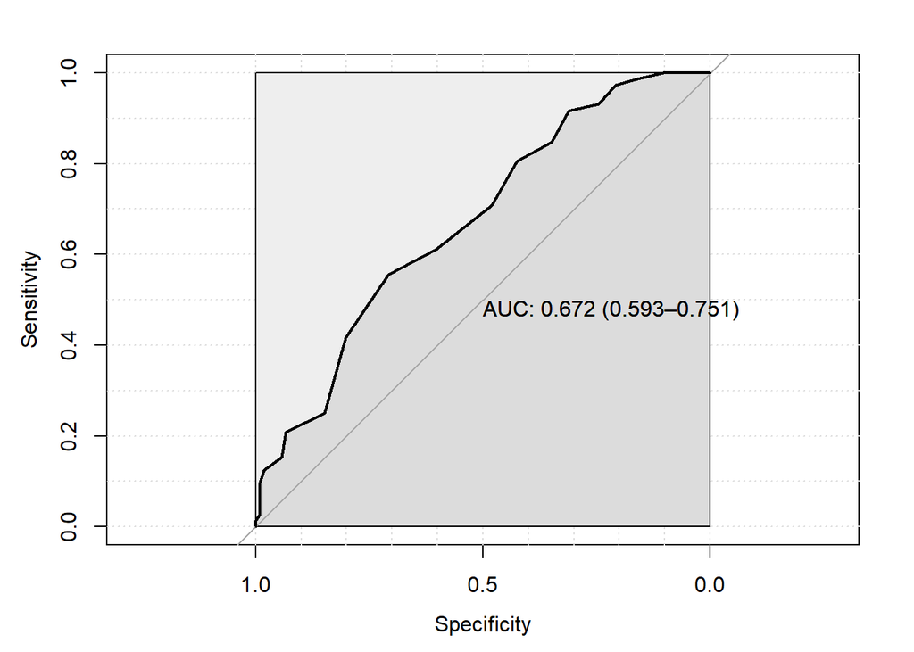

```r
# Generate ROC curve and calculate confidence intervals
pROC_obj <- roc(das28_remission_week12$remission, das28_remission_week12$gpq,
                smoothed = TRUE,
                # Arguments for confidence intervals
                ci = TRUE, ci.alpha = 0.90, stratified = FALSE,
                # Arguments for plot
                plot = TRUE, auc.polygon = TRUE, max.auc.polygon = TRUE, grid = TRUE,
                print.auc = TRUE, show.thres = TRUE)
```

```r
pROC_obj[["auc"]]
```

```
## Area under the curve: 0.67
```

```r
pROC_obj[["ci"]]
```

```
## 95% CI: 0.59-0.75 (DeLong)
```

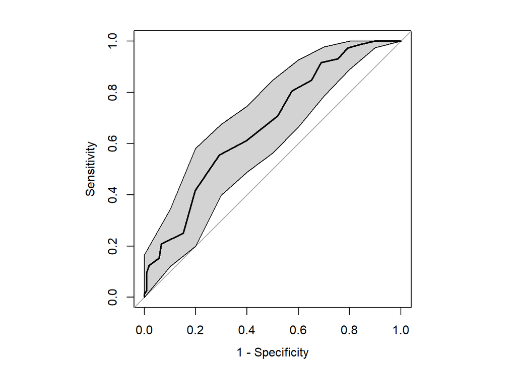

```r
# Calculate sensitivity confidence intervals
sens.ci <- ci.se(pROC_obj)

# Plot the ROC curve with corrected axis limits
par(pty = "s") ## "s" - creates a square plotting region
plot(pROC_obj, xlim = c(1, 0), ylim = c(0, 1),
     col = "blue", lwd = 2,
     # main = "ROC curve with 95% confidence intervals",
     legacy.axes = TRUE,
     print.auc = FALSE,
     )

# Add the confidence intervals as shaded areas
plot(sens.ci, type = "shape", col = "lightgrey", add = TRUE)
```

```r
## Finding out the optimal threshold
## Store the relevant data used to make the ROC graph in a list
roc.info <- roc(das28_remission_week12$remission, das28_remission_week12$gpq, legacy.axes=TRUE)
str(roc.info)
```

[output not shown]

```r
## and then extract just the information that we want from that variable.
# Create a dataframe with all thresholds and their corresponding metrics
roc.df <- data.frame(
  thresholds = roc.info$thresholds,
  sensitivities = roc.info$sensitivities,
  specificities = roc.info$specificities,
  youden_index = roc.info$sensitivities + roc.info$specificities - 1
)
```

Save ROC curve plot as TIFF file.

```r
# Generate ROC curve without plotting and without automatic text annotations
roc_info <- roc(response = das28_remission_week12$remission, predictor = das28_remission_week12$gpq,
                smoothed = TRUE, ci = TRUE, ci.alpha = 0.9, stratified = FALSE,
                plot = FALSE)

# Calculate sensitivity confidence intervals
sens.ci <- ci.se(roc_info)

# Open TIFF device
tiff("ROC_Curve_Remission_12weeks.tiff", width = 2400, height = 2400, res = 300,
     compression = "lzw")

# Initialize the plotting area with reversed x-axis limits and larger fonts
plot(roc_info, col = "blue", lwd = 2,
     xlab = "1 - Specificity", ylab = "Sensitivity",
     xlim = c(1, 0), ylim = c(0, 1), legacy.axes = TRUE,
     cex.lab = 1.8,  # Increase axis labels size
     cex.axis = 1.5,  # Increase axis tick labels size
     cex.main = 1,  # Increase main title size
     main = "")

# Add the confidence intervals as shaded areas
plot(sens.ci, type = "shape", col = "lightgrey", add = TRUE)

# Add AUC text with increased font size
text(0.6, 0.2, paste("AUC =", round(roc_info$auc, 2)), col = "black", cex = 1.5)

# Add large capital A in the upper left corner
text(x = 0.95, y = 0.95, labels = "A", cex = 3, col = "black", font = 2)

# Close the TIFF device
dev.off()
```

ROC 24 weeks

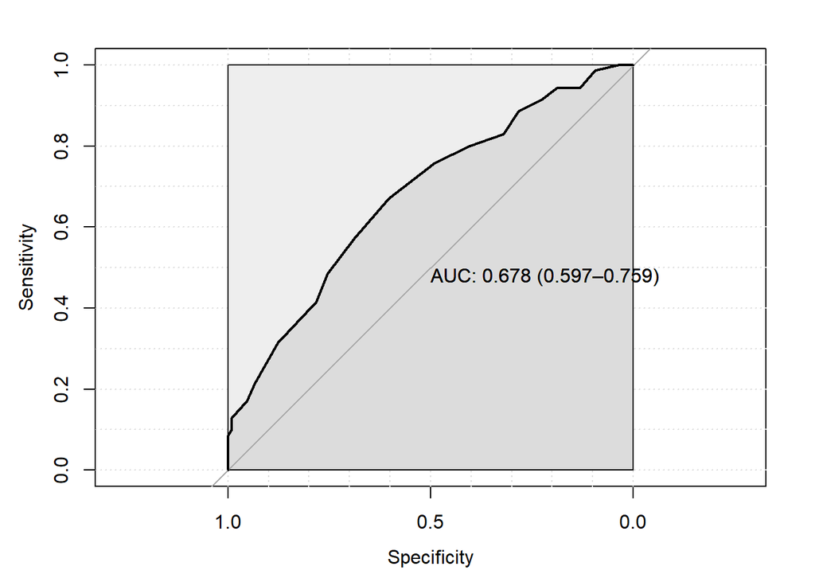

```r
# Generate ROC curve and calculate confidence intervals
pROC_obj <- roc(das28_remission_week24$remission, das28_remission_week24$gpq,
                smoothed = TRUE,
                # Arguments for confidence intervals
                ci = TRUE, ci.alpha = 0.90, stratified = FALSE,
                # Arguments for plot
                plot = TRUE, auc.polygon = TRUE, max.auc.polygon = TRUE, grid = TRUE,
                print.auc = TRUE, show.thres = TRUE)
```

```r
pROC_obj[["auc"]]
```

```
## Area under the curve: 0.68
```

```r
pROC_obj[["ci"]]
```

```
## 95% CI: 0.6-0.76 (DeLong)
```

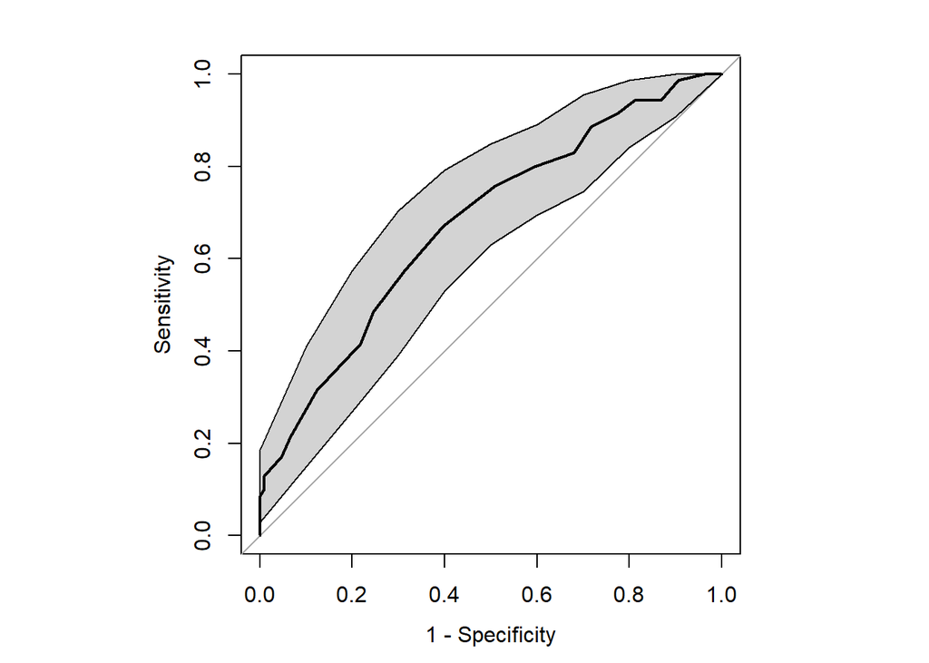

```r
# Calculate sensitivity confidence intervals
sens.ci <- ci.se(pROC_obj)

# Plot the ROC curve with corrected axis limits
par(pty = "s") ## "s" - creates a square plotting region
plot(pROC_obj, xlim = c(1, 0), ylim = c(0, 1),
     col = "blue", lwd = 2,
     # main = "ROC curve with 95% confidence intervals",
     legacy.axes = TRUE,
     print.auc = FALSE,
     )

# Add the confidence intervals as shaded areas
plot(sens.ci, type = "shape", col = "lightgrey", add = TRUE)
```

```r
## Finding out the optimal threshold
## Store the relevant data used to make the ROC graph in a list
roc.info <- roc(das28_remission_week24$remission, das28_remission_week24$gpq, legacy.axes=TRUE)
str(roc.info)
```

[output not shown]

```r
## and then extract just the information that we want from that variable.
# Create a dataframe with all thresholds and their corresponding metrics
roc.df <- data.frame(
  thresholds = roc.info$thresholds,
  sensitivities = roc.info$sensitivities,
  specificities = roc.info$specificities,
  youden_index = roc.info$sensitivities + roc.info$specificities - 1
)
```

Save ROC curve plot as TIFF file.

```r
# Generate ROC curve without plotting and without automatic text annotations
roc_info <- roc(response = das28_remission_week24$remission, predictor = das28_remission_week24$gpq,
                smoothed = TRUE, ci = TRUE, ci.alpha = 0.9, stratified = FALSE,
                plot = FALSE)

# Calculate sensitivity confidence intervals
sens.ci <- ci.se(roc_info)

# Open TIFF device
tiff("ROC_Curve_Remission_24weeks.tiff", width = 2400, height = 2400, res = 300,
     compression = "lzw")

# Initialize the plotting area with reversed x-axis limits and larger fonts
plot(roc_info, col = "blue", lwd = 2,
     xlab = "1 - Specificity", ylab = "Sensitivity",
     xlim = c(1, 0), ylim = c(0, 1), legacy.axes = TRUE,
     cex.lab = 1.8,  # Increase axis labels size
     cex.axis = 1.5,  # Increase axis tick labels size
     cex.main = 1,  # Increase main title size
     main = "")

# Add the confidence intervals as shaded areas
plot(sens.ci, type = "shape", col = "lightgrey", add = TRUE)

# Add AUC text with increased font size
text(0.6, 0.2, paste("AUC =", round(roc_info$auc, 2)), col = "black", cex = 1.5)

# Add large capital B in the upper left corner
text(x = 0.95, y = 0.95, labels = "B", cex = 3, col = "black", font = 2)

# Close the TIFF device
dev.off()
```

ROC 36 weeks

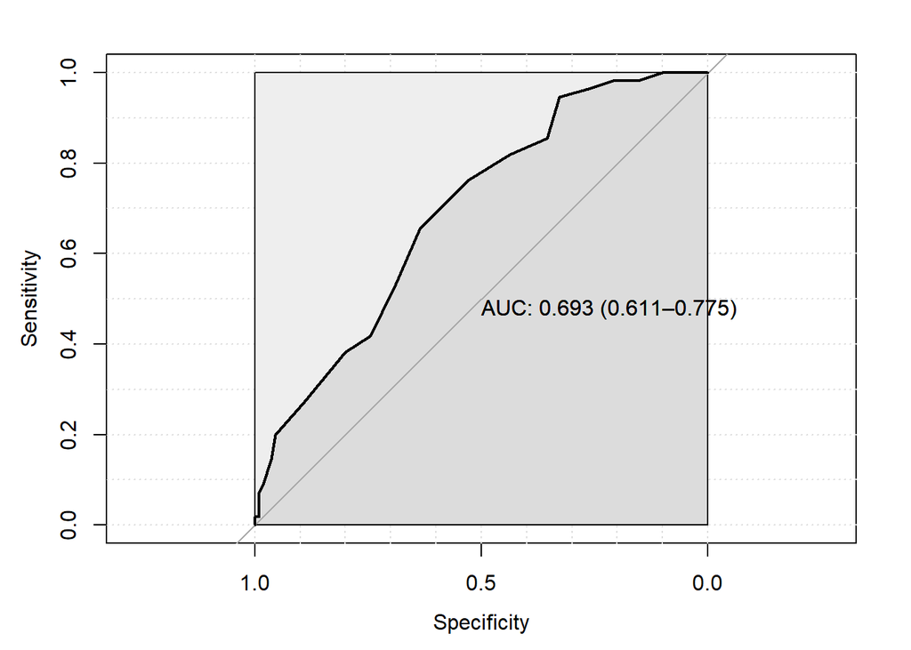

```r
# Generate ROC curve and calculate confidence intervals
pROC_obj <- roc(das28_remission_week36$remission, das28_remission_week36$gpq,
                smoothed = TRUE,
                # Arguments for confidence intervals
                ci = TRUE, ci.alpha = 0.90, stratified = FALSE,
                # Arguments for plot
                plot = TRUE, auc.polygon = TRUE, max.auc.polygon = TRUE, grid = TRUE,
                print.auc = TRUE, show.thres = TRUE)
```

```r
pROC_obj[["auc"]]
```

```
## Area under the curve: 0.69
```

```r
pROC_obj[["ci"]]
```

```
## 95% CI: 0.61-0.78 (DeLong)
```

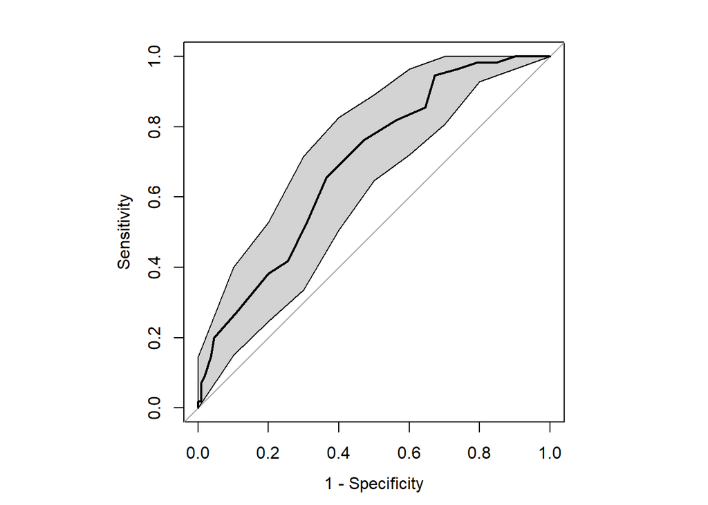

```r
# Calculate sensitivity confidence intervals
sens.ci <- ci.se(pROC_obj)

# Plot the ROC curve with corrected axis limits
par(pty = "s") ## "s" - creates a square plotting region
plot(pROC_obj, xlim = c(1, 0), ylim = c(0, 1),
     col = "blue", lwd = 2,
     # main = "ROC curve with 95% confidence intervals",
     legacy.axes = TRUE,
     print.auc = FALSE,
     )

# Add the confidence intervals as shaded areas
plot(sens.ci, type = "shape", col = "lightgrey", add = TRUE)
```

```r
## Finding out the optimal threshold
## Store the relevant data used to make the ROC graph in a list
roc.info <- roc(das28_remission_week36$remission, das28_remission_week36$gpq, legacy.axes=TRUE)
str(roc.info)
```

[output not shown]

```r
## and then extract just the information that we want from that variable.
# Create a dataframe with all thresholds and their corresponding metrics
roc.df <- data.frame(
  thresholds = roc.info$thresholds,
  sensitivities = roc.info$sensitivities,
  specificities = roc.info$specificities,
  youden_index = roc.info$sensitivities + roc.info$specificities - 1
)
```

Save ROC curve plot as TIFF file.

```r
# Generate ROC curve without plotting and without automatic text annotations
roc_info <- roc(response = das28_remission_week36$remission, predictor = das28_remission_week36$gpq,
                smoothed = TRUE, ci = TRUE, ci.alpha = 0.9, stratified = FALSE,
                plot = FALSE)

# Calculate sensitivity confidence intervals
sens.ci <- ci.se(roc_info)

# Open TIFF device
tiff("ROC_Curve_Remission_36weeks.tiff", width = 2400, height = 2400, res = 300,
     compression = "lzw")

# Initialize the plotting area with reversed x-axis limits and larger fonts
plot(roc_info, col = "blue", lwd = 2,
     xlab = "1 - Specificity", ylab = "Sensitivity",
     xlim = c(1, 0), ylim = c(0, 1), legacy.axes = TRUE,
     cex.lab = 1.8,  # Increase axis labels size
     cex.axis = 1.5,  # Increase axis tick labels size
     cex.main = 1,  # Increase main title size
     main = "")

# Add the confidence intervals as shaded areas
plot(sens.ci, type = "shape", col = "lightgrey", add = TRUE)

# Add AUC text with increased font size
text(0.6, 0.2, paste("AUC =", round(roc_info$auc, 2)), col = "black", cex = 1.5)

# Add large capital C in the upper left corner
text(x = 0.95, y = 0.95, labels = "C", cex = 3, col = "black", font = 2)

# Close the TIFF device
dev.off()
```

ROC 48 weeks

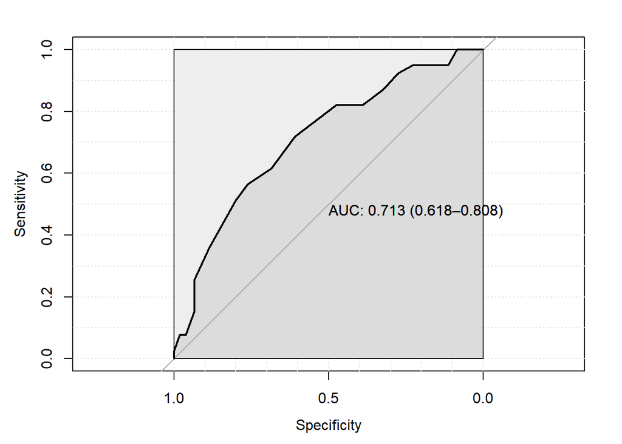

```r
# Generate ROC curve and calculate confidence intervals
pROC_obj <- roc(das28_remission_week48$remission, das28_remission_week48$gpq,
                smoothed = TRUE,
                # Arguments for confidence intervals
                ci = TRUE, ci.alpha = 0.90, stratified = FALSE,
                # Arguments for plot
                plot = TRUE, auc.polygon = TRUE, max.auc.polygon = TRUE, grid = TRUE,
                print.auc = TRUE, show.thres = TRUE)
```

```r
pROC_obj[["auc"]]
```

```
## Area under the curve: 0.71
```

```r
pROC_obj[["ci"]]
```

```
## 95% CI: 0.62-0.81 (DeLong)
```

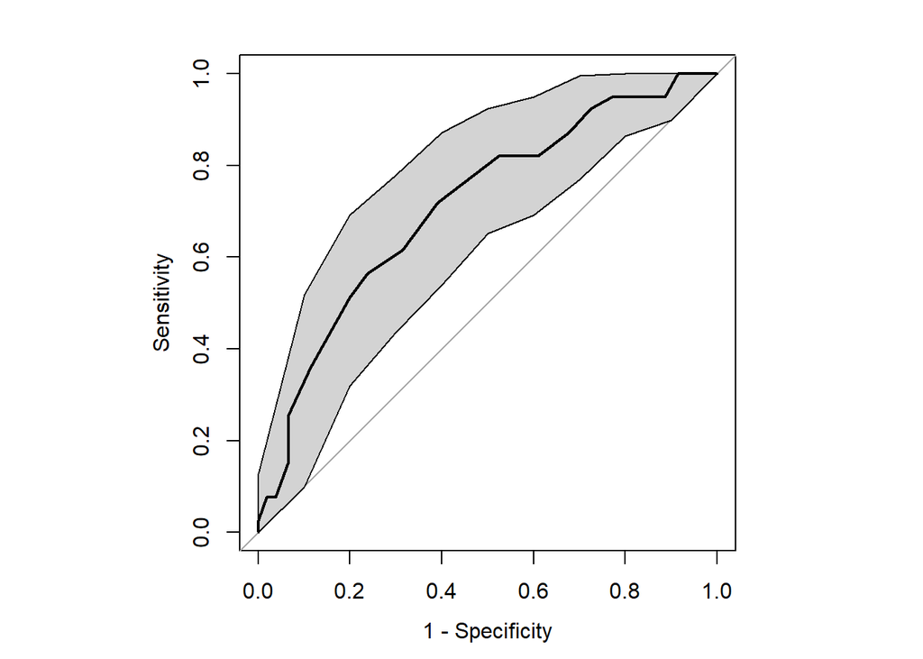

```r
# Calculate sensitivity confidence intervals
sens.ci <- ci.se(pROC_obj)

# Plot the ROC curve with corrected axis limits
par(pty = "s") ## "s" - creates a square plotting region
plot(pROC_obj, xlim = c(1, 0), ylim = c(0, 1),
     col = "blue", lwd = 2,
     # main = "ROC curve with 95% confidence intervals",
     legacy.axes = TRUE,
     print.auc = FALSE,
     )

# Add the confidence intervals as shaded areas
plot(sens.ci, type = "shape", col = "lightgrey", add = TRUE)
```

```r
## Finding out the optimal threshold
## Store the relevant data used to make the ROC graph in a list
roc.info <- roc(das28_remission_week48$remission, das28_remission_week48$gpq, legacy.axes=TRUE)
str(roc.info)
```

[output not shown]

```r
## and then extract just the information that we want from that variable.
# Create a dataframe with all thresholds and their corresponding metrics
roc.df <- data.frame(
  thresholds = roc.info$thresholds,
  sensitivities = roc.info$sensitivities,
  specificities = roc.info$specificities,
  youden_index = roc.info$sensitivities + roc.info$specificities - 1
)


# Find the threshold with the maximum Youden Index
max_youden <- roc.df[which.max(roc.df$youden_index), ]

# Print the GPQ score with the highest Youden Index, and its sensitivity and specificity
cat("Optimal GPQ Score (Threshold):", max_youden$thresholds, "\n",
    "Sensitivity at Optimal Threshold:", max_youden$sensitivities, "\n",
    "Specificity at Optimal Threshold:", max_youden$specificities, "\n",
    "Maximum Youden Index:", max_youden$youden_index, "\n")
```

```
## Optimal GPQ Score (Threshold): 9.5
##  Sensitivity at Optimal Threshold: 0.72
##  Specificity at Optimal Threshold: 0.61
##  Maximum Youden Index: 0.33
```

Save ROC curve plot as TIFF file.

```r
# Generate ROC curve without plotting and without automatic text annotations
roc_info <- roc(response = das28_remission_week48$remission, predictor = das28_remission_week48$gpq,
                smoothed = TRUE, ci = TRUE, ci.alpha = 0.9, stratified = FALSE,
                plot = FALSE)

# Calculate sensitivity confidence intervals
sens.ci <- ci.se(roc_info)

# Open TIFF device
tiff("ROC_Curve_Remission_48weeks.tiff", width = 2400, height = 2400, res = 300,
     compression = "lzw")

# Initialize the plotting area with reversed x-axis limits and larger fonts
plot(roc_info, col = "blue", lwd = 2,
     xlab = "1 - Specificity", ylab = "Sensitivity",
     xlim = c(1, 0), ylim = c(0, 1), legacy.axes = TRUE,
     cex.lab = 1.8,  # Increase axis labels size
     cex.axis = 1.5,  # Increase axis tick labels size
     cex.main = 1,  # Increase main title size
     main = "")

# Add the confidence intervals as shaded areas
plot(sens.ci, type = "shape", col = "lightgrey", add = TRUE)

# Add AUC text with increased font size
text(0.6, 0.2, paste("AUC =", round(roc_info$auc, 2)), col = "black", cex = 1.5)

# Add large capital D in the upper left corner
text(x = 0.95, y = 0.95, labels = "D", cex = 3, col = "black", font = 2)

# Close the TIFF device
dev.off()
```

Combining the ROC curve plots

```
## # A tibble: 1 × 7
##   format width height colorspace matte filesize density
##   <chr>  <int>  <int> <chr>      <lgl>    <int> <chr>
## 1 TIFF    4800   4800 sRGB       FALSE        0 300x300
```

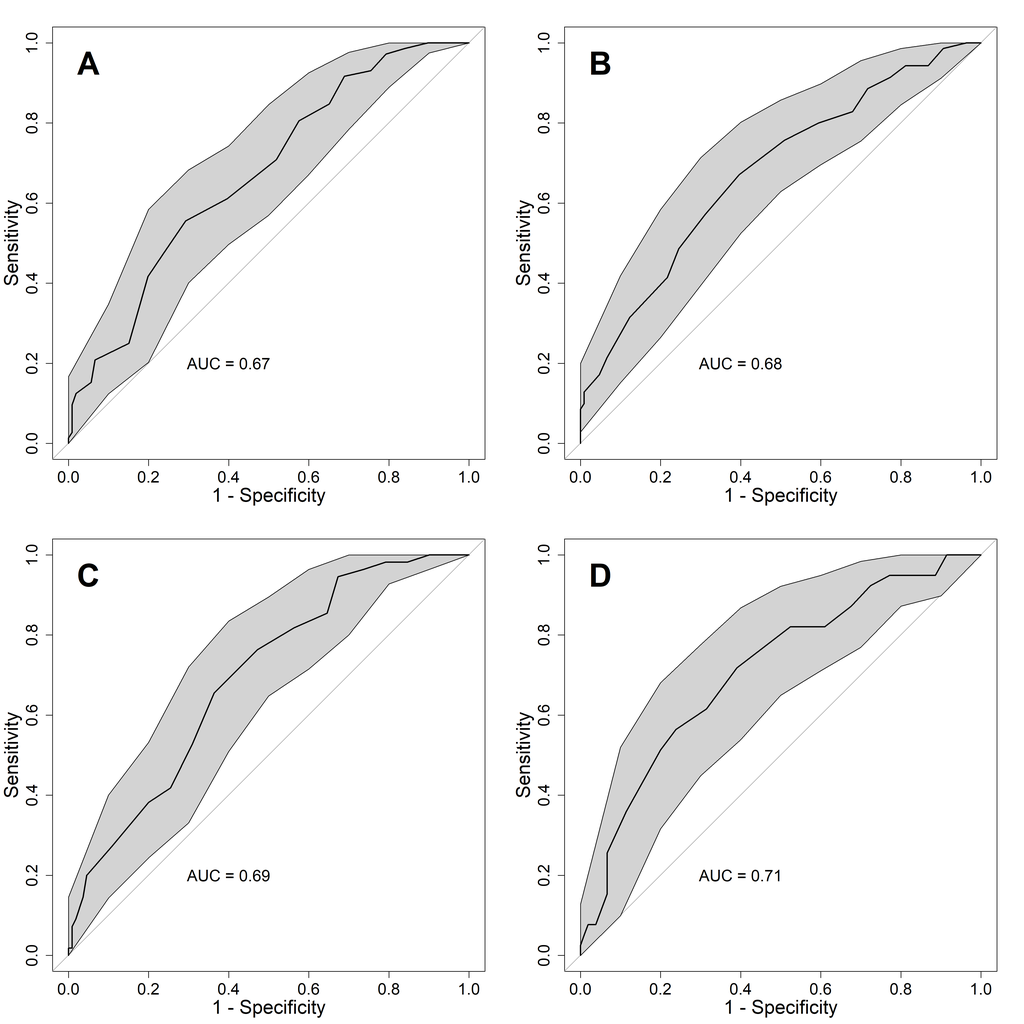

```r
# Save combined plot for ROC curves

plot1 <- image_read("ROC_Curve_Remission_12weeks.tiff")
plot2 <- image_read("ROC_Curve_Remission_24weeks.tiff")
plot3 <- image_read("ROC_Curve_Remission_36weeks.tiff")
plot4 <- image_read("ROC_Curve_Remission_48weeks.tiff")

# Append images in rows first, then append the rows
row1 <- image_append(c(plot1, plot2))
row2 <- image_append(c(plot3, plot4))
ROC_combined_plot <- image_append(c(row1, row2), stack = TRUE)

# Save the image as a TIFF with 300 DPI resolution
image_write(ROC_combined_plot, "ROC_combined_plot.tiff")

# To display in R viewer
print(ROC_combined_plot)
```

# Using `sample_ACR50` dataframe for linear mixed effects analyses of disease activity parameters over time

## Merging ACR50 and disease activity components

Join on time point (week):

```r
# Merge (full_join) the different components,
# starting with the dataframe with most entries (das28)

ACR50 <- full_join(das28, crp_bse, by = c(
    "patient_id" = "patient_id",
    "week" = "week")) %>%
dplyr::select(-start_date.x, -diff_in_weeks.x, -start_date.y, -diff_in_weeks.y)

ACR50 <- full_join(ACR50, physician_global, by = c(
    "patient_id" = "patient_id",
    "week" = "week")) %>%
dplyr::select(-start_date, -diff_in_weeks)

ACR50 <- full_join(ACR50, wellbeing, by = c(
    "patient_id" = "patient_id",
    "week" = "week")) %>%
dplyr::select(-start_date, -diff_in_weeks)

ACR50 <- full_join(ACR50, pain, by = c(
    "patient_id" = "patient_id",
    "week" = "week")) %>%
dplyr::select(-start_date, -diff_in_weeks)

ACR50 <- full_join(ACR50, rapid3_haq, by = c(
    "patient_id" = "patient_id",
    "week" = "week")) %>%
dplyr::select(-start_date, -diff_in_weeks)

ACR50 <- ACR50 %>%
  arrange(patient_id, week) %>%
  # moving patient_id to first column
  dplyr::select(patient_id, week, everything())

count(ACR50, week)
```

```
## # A tibble: 7 × 2
##    week     n
##   <dbl> <int>
## 1     0   199
## 2     4   169
## 3     8   162
## 4    12   191
## 5    24   188
## 6    36   180
## 7    48   168
```

```r
# Number of patients with available measurements at each timepoint

miss_var_summary(ACR50)
```

```
## # A tibble: 20 × 3
##    variable              n_miss pct_miss
##    <chr>                  <int>    <dbl>
##  1 score                    541    43.0
##  2 date_bse                 446    35.5
##  3 bse                      446    35.5
##  4 date_physician_global    396    31.5
##  5 physician_global         396    31.5
##  6 date_das28               380    30.2
##  7 tjc28                    380    30.2
##  8 sjc28                    380    30.2
##  9 jc28                     380    30.2
## 10 delta_tsjc28             380    30.2
## 11 date_crp                 370    29.4
## 12 crp                      370    29.4
## 13 date_pain                164    13.0
## 14 pain                     164    13.0
## 15 date_rapid3_haq          164    13.0
## 16 rapid3_haq               164    13.0
## 17 date_wellbeing            62     4.93
## 18 wellbeing                 62     4.93
## 19 patient_id                 0     0
## 20 week                       0     0
```

```r
# Explore missing data
```

## Compute DAS28, SDAI and CDAI scores

```r
# If wellbeing or crp are missing (but not joint counts) impute with simpuation by means of robust linear regression through M-estimation, using the patient’s values for the remaining components of the DAS28
set.seed(2022001)
ACR50 <- ACR50 %>%
  impute_rlm(wellbeing ~ sjc28 + tjc28 + crp, add_residual="observed") %>%
  impute_rlm(wellbeing ~ sjc28 + tjc28, add_residual="observed") %>%
  impute_rlm(crp ~ sjc28 + tjc28 + wellbeing, add_residual="observed") %>%
  impute_rlm(crp ~ sjc28 + tjc28, add_residual="observed") %>%
  # Round imputed values and set min and max limits
  mutate_if(is.numeric, round) %>%
  mutate(wellbeing = ifelse(wellbeing < 0, 0, wellbeing)) %>%
  mutate(wellbeing = ifelse(wellbeing > 100, 100, wellbeing)) %>%
  mutate(crp = ifelse(crp < 1, 0, crp)) %>%
  mutate(crp = ifelse(crp > 99, 100, crp))

# Explore missing data
miss_var_summary(ACR50)
```

```
## # A tibble: 20 × 3
##    variable              n_miss pct_miss
##    <chr>                  <int>    <dbl>
##  1 score                    541    43.0
##  2 date_bse                 446    35.5
##  3 bse                      446    35.5
##  4 date_physician_global    396    31.5
##  5 physician_global         396    31.5
##  6 date_das28               380    30.2
##  7 tjc28                    380    30.2
##  8 sjc28                    380    30.2
##  9 jc28                     380    30.2
## 10 delta_tsjc28             380    30.2
## 11 date_crp                 370    29.4
## 12 crp                      347    27.6
## 13 date_pain                164    13.0
## 14 pain                     164    13.0
## 15 date_rapid3_haq          164    13.0
## 16 rapid3_haq               164    13.0
## 17 date_wellbeing            62     4.93
## 18 wellbeing                 19     1.51
## 19 patient_id                 0     0
## 20 week                       0     0
```

```r
# Compute disease activity indices
ACR50 <- ACR50 %>%
  mutate(DAS28_CRP = 0.56*sqrt(tjc28) + 0.28*sqrt(sjc28) + 0.36*log(crp + 1)
         + 0.014*wellbeing + 0.96) %>%
  mutate(DAS28_ESR = 0.56*sqrt(tjc28) + 0.28*sqrt(sjc28) + 0.70*log(bse)
         + 0.014*wellbeing) %>%
  mutate(SDAI = sjc28 + tjc28 + (wellbeing / 10) + (physician_global / 10) +
           (crp / 10)) %>% ## CRP mg/dl and globals on 0-10 scale
  mutate(CDAI = sjc28 + tjc28 + (wellbeing / 10) + (physician_global / 10))
```

## Merging `ACR50` dataframe with `sample` dataframe

```r
# Merge (full_join) the different components,
# starting with the dataframe with most entries (das28)

sample_ACR50 <- full_join(sample, ACR50, by = c(
    "patient_id" = "patient_id")) %>%

  # Include rows for missing observations !!!
  complete(nesting(!!!dplyr::select(.,patient_id:concomitant_mtx)),
           week = (c(0,4,8,12,24,36,48)))
```

```r
# Select only relevant weeks rows
sample_ACR50_lmm <- sample_ACR50 %>%
  filter(week == "0" | week == "12" | week == "24" | week == "36" | week == "48") %>%

# Include rows for missing observations !!!
complete(nesting(!!!dplyr::select(.,patient_id:depression)),
         week = (c(0,4,8,12,24,36,48)))

# Add time as factor to the dataframe to obtain EM means:
sample_ACR50_lmm <- mutate(sample_ACR50_lmm, fweek = factor(week))
```